# Advanced Data Analysis with R

Rabindra Adhikari

2024-03-03

# Loading Datasets

```r
inflation_rate_cpi <- read.csv("data/inflation_rate_cpi.csv")
unemployment_rate <- read.csv("data/unemployment_rate.csv")
```

# Separating the data based on countries and converting into time series

```r
# Convert the Time column to a Date type
unemployment_rate <- unemployment_rate %>%
  mutate(Time = ymd(paste(Time, "01", sep = "-")))

inflation_rate_cpi <- inflation_rate_cpi %>%
  mutate(Time = ymd(paste(Time, "01", sep = "-")))

# Creating time series for each country and dataset

# Spain

spain_unemployment <- unemployment_rate %>%
  filter(Country == "Spain")
SPN_UE_TS <- ts(spain_unemployment$Value, start=c(2000,1), frequency=12)

spain_inflation_rate <- inflation_rate_cpi %>%
  filter(Country == "Spain")
SPN_I_TS <- ts(spain_inflation_rate$Value, start=c(2000,1), frequency=12)

# Germany

germany_unemployment <- unemployment_rate %>%
  filter(Country == "Germany")
GER_UE_TS <- ts(germany_unemployment$Value, start=c(2000,1), frequency=12)

germany_inflation_rate <- inflation_rate_cpi %>%
  filter(Country == "Germany")
GER_I_TS <- ts(germany_inflation_rate$Value, start=c(2000,1), frequency=12)

# Portugal

portugal_unemployment <- unemployment_rate %>%
  filter(Country == "Portugal")
POR_UE_TS <- ts(portugal_unemployment$Value, start=c(2000,1), frequency=12)

portugal_inflation_rate <- inflation_rate_cpi %>%
  filter(Country == "Portugal")
POR_I_TS <- ts(portugal_inflation_rate$Value, start=c(2000,1), frequency=12)
```

# Defining time frame to split data

```r
# Define the start and end points for the training set
start_train <- c(2000, 01)  # Start of the training set (January 2000)
end_train <- c(2017, 12)   # End of the training set (December 2017)

# Define the start and end points for the test set
start_test <- c(2018, 01)   # Start of the test set (January 2018)
end_test <- c(2019, 12)     # End of the test set (December 2019)
```

# GERMANY

## Splitting the dataset

```r
# Inflation Data

# Create the training set
GER_I_train <- window(GER_I_TS, start=start_train, end=end_train)

# Create the test set
GER_I_test <- window(GER_I_TS, start=start_test, end=end_test)

# Unemployment Data

# Create the training set
GER_UE_train <- window(GER_UE_TS, start=start_train, end=end_train)

# Create the test set
GER_UE_test <- window(GER_UE_TS, start=start_test, end=end_test)
```

## Descriptive Statistics of the Data

```r
print("Germany Inflation Rate Data Summary:")
```

```
## [1] "Germany Inflation Rate Data Summary:"
```

```r
summary(GER_I_train)
```

```
##    Min. 1st Qu.  Median    Mean 3rd Qu.    Max.
## -0.5025  1.0417  1.4313  1.4463  1.9004  3.3229
```

```r
cat("\n")
```

```r
print("Germany Unemployment Rate Data Summary:")
```

```
## [1] "Germany Unemployment Rate Data Summary:"
```

```r
summary(GER_UE_train)
```

```
##    Min. 1st Qu.  Median    Mean 3rd Qu.    Max.
##   3.400   4.900   7.300   7.074   8.900  11.200
```

## Plotting Histogram

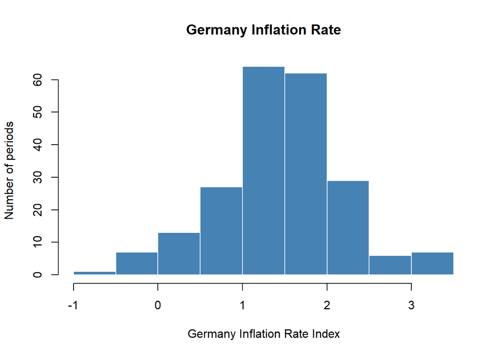

```r
# Inflation Germany
hist(GER_I_train,col='steelblue', border = "white", xlab = 'Germany Inflation Rate Index', ylab = 'Number of periods', main = 'Germany Inflation Rate')
```

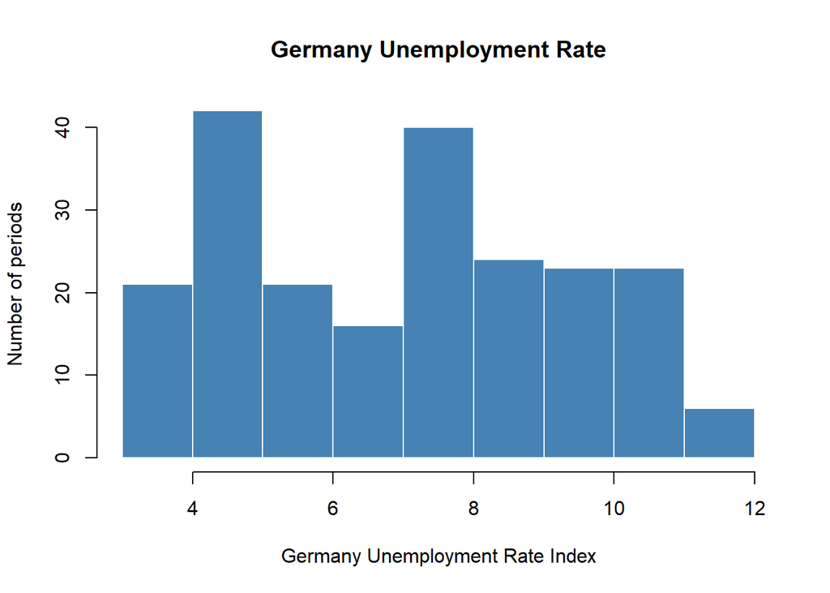

```r
# Unemployment Germany
hist(GER_UE_train,col='steelblue', border = "white", xlab = 'Germany Unemployment Rate Index', ylab = 'Number of periods', main = 'Germany Unemployment Rate')
```

## Time Series Decomposition

```r
GER_I_train_decomposed <- decompose(GER_I_train)
GER_UE_train_decomposed <- decompose(GER_UE_train)
```

## Plot the decomposed series

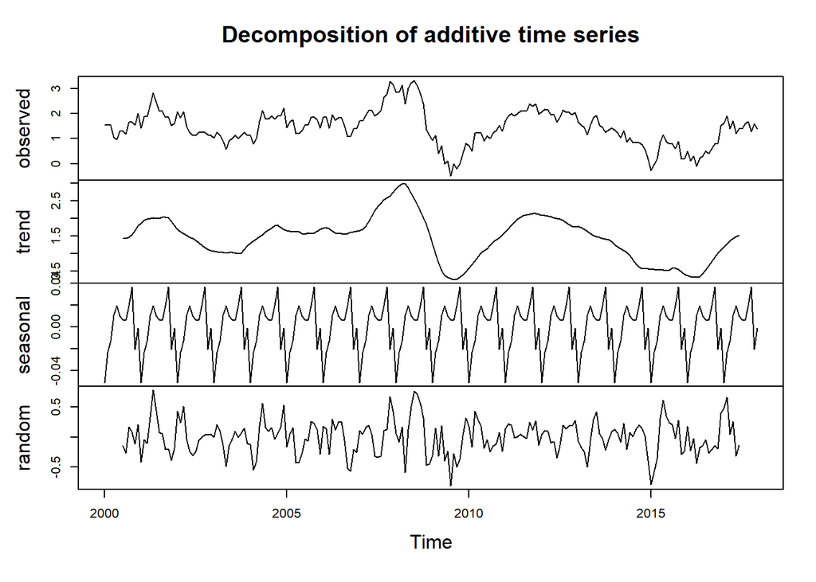

```r
plot(GER_I_train_decomposed)
```

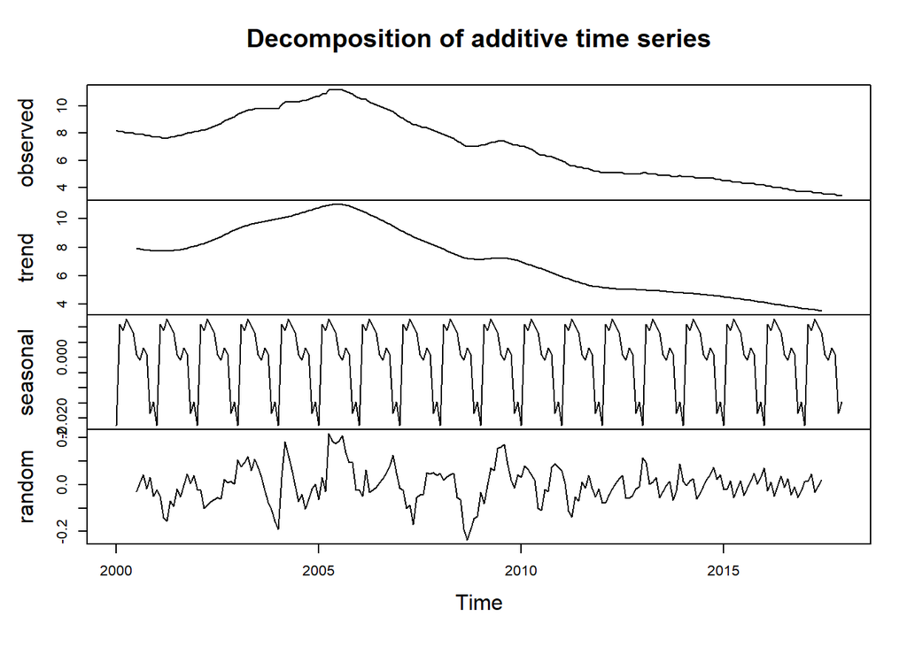

```r
plot(GER_UE_train_decomposed)
```

## Box-Cox Transformation

```r
BoxCox.lambda(GER_I_train)
```

```
## [1] 0.9508625
```

For Germany Inflation series, we do not need to apply box-cox transformation as the lambda value is close to 1.

```r
BoxCox.lambda(GER_UE_train)
```

```
## [1] -0.007616981
```

For Germany Unemployment series, we do need to apply box-cox transformation.

```r
lambda_ger_ue <- -0.007616981
GER_UE_train_BoxCox <- BoxCox(GER_UE_train, lambda = lambda_ger_ue)
```

## Stationarity Check

### ADF Test

```r
# Augmented Dickey-Fuller Test
adf.test(GER_I_train)
```

```
##
##  Augmented Dickey-Fuller Test
##
## data:  GER_I_train
## Dickey-Fuller = -3.0127, Lag order = 5, p-value = 0.1512
## alternative hypothesis: stationary
```

```r
adf.test(GER_UE_train_BoxCox)
```

```
##
##  Augmented Dickey-Fuller Test
##
## data:  GER_UE_train_BoxCox
## Dickey-Fuller = -2.3028, Lag order = 5, p-value = 0.449
## alternative hypothesis: stationary
```

### KPSS Test

```r
# KPSS Test
kpss.test(GER_I_train)
```

```
##
##  KPSS Test for Level Stationarity
##
## data:  GER_I_train
## KPSS Level = 0.51048, Truncation lag parameter = 4, p-value = 0.03931
```

```r
kpss.test(GER_UE_train_BoxCox)
```

```
##
##  KPSS Test for Level Stationarity
##
## data:  GER_UE_train_BoxCox
## KPSS Level = 3.7783, Truncation lag parameter = 4, p-value = 0.01
```

## Result of ADF and KPSS Test

GER_I_train (Germany Inflation Rate Training Set)

- ADF Test: p-value = 0.1512
- KPSS Test: p-value = 0.03931

GER_UE_train_BoxCox (Germany Unemployment Rate Training Set)

- ADF Test: p-value = 0.449
- KPSS Test: p-value = smaller than 0.01

So, based on these results:

- For GER_I_train, both tests show non-stationarity. So, we have to apply differencing to this series.
- For GER_UE_train_BoxCox as well, both tests show non-stationarity. We definitely have to apply differencing to this series.

## First-Order Differences

```r
GER_I_train_diff1 <- diff(GER_I_train)
GER_UE_train_diff1 <- diff(GER_UE_train_BoxCox)
```

## Stationarity Check Again

### ADF Test on the First-Order Differenced Series

```r
adf.test(GER_I_train_diff1)
```

```
##
##  Augmented Dickey-Fuller Test
##
## data:  GER_I_train_diff1
## Dickey-Fuller = -6.2868, Lag order = 5, p-value = 0.01
## alternative hypothesis: stationary
```

```r
adf.test(GER_UE_train_diff1)
```

```
##
##  Augmented Dickey-Fuller Test
##
## data:  GER_UE_train_diff1
## Dickey-Fuller = -4.0188, Lag order = 5, p-value = 0.01
## alternative hypothesis: stationary
```

### KPSS Test on the First-Order Differenced Series

```r
# KPSS Test
kpss.test(GER_I_train_diff1)
```

```
##
##  KPSS Test for Level Stationarity
##
## data:  GER_I_train_diff1
## KPSS Level = 0.030093, Truncation lag parameter = 4, p-value = 0.1
```

```r
kpss.test(GER_UE_train_diff1)
```

```
##
##  KPSS Test for Level Stationarity
##
## data:  GER_UE_train_diff1
## KPSS Level = 1.1407, Truncation lag parameter = 4, p-value = 0.01
```

## Result of ADF and KPSS Test on First-Order Differenced Series

GER_I_train (Germany Inflation Rate Training Set)

- ADF Test: p-value = smaller than 0.01
- KPSS Test: p-value = greater than 0.1

GER_UE_train (Germany Unemployment Rate Training Set)

- ADF Test: p-value = smaller than 0.01
- KPSS Test: p-value = smaller than 0.01

## Second-Order Differencing

```r
GER_UE_train_diff2 <- diff(GER_UE_train_diff1)
```

## Stationarity Check for Unemployment Series

### ADF Test on the Second-Order Differenced Series

```r
adf.test(GER_UE_train_diff2)
```

```
##
##  Augmented Dickey-Fuller Test
##
## data:  GER_UE_train_diff2
## Dickey-Fuller = -8.8712, Lag order = 5, p-value = 0.01
## alternative hypothesis: stationary
```

### KPSS Test on the Second-Order Differenced Series

```r
# KPSS Test
kpss.test(GER_UE_train_diff2)
```

```
##
##  KPSS Test for Level Stationarity
##
## data:  GER_UE_train_diff2
## KPSS Level = 0.022059, Truncation lag parameter = 4, p-value = 0.1
```

## Result of ADF and KPSS Test on Second-Order Differenced Series for Unemployment Data

GER_UE_train (Germany Unemployment Rate Training Set)

- ADF Test: p-value = smaller than 0.01
- KPSS Test: p-value = greater than 0.1

Based on these results, GER_UE_train_diff2 is stationary.

## Autocorrelation Function and Partial-Autocorrelation Function (ACF & PACF)

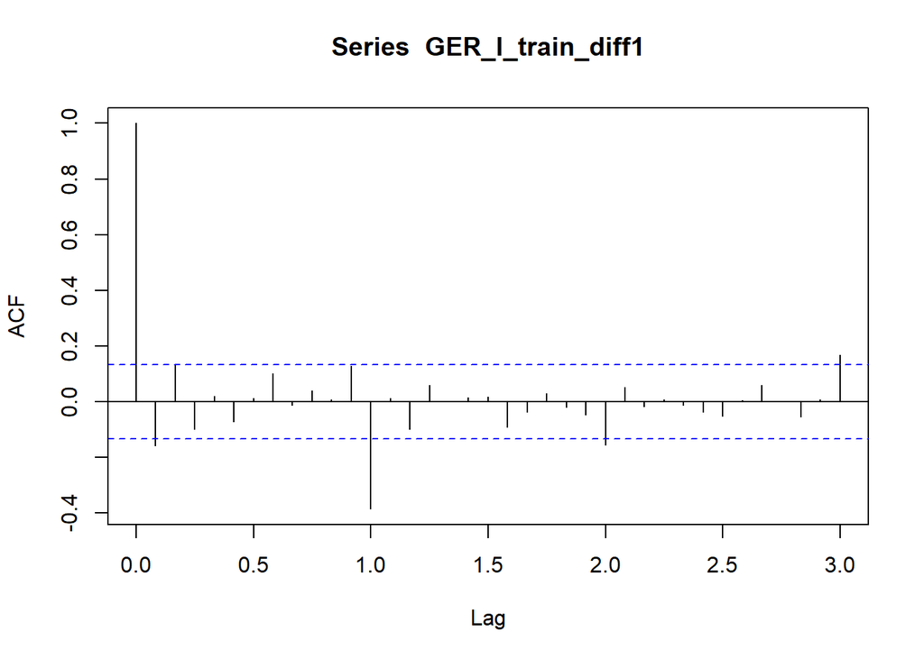

```r
acf(GER_I_train_diff1, lag.max = 36)
```

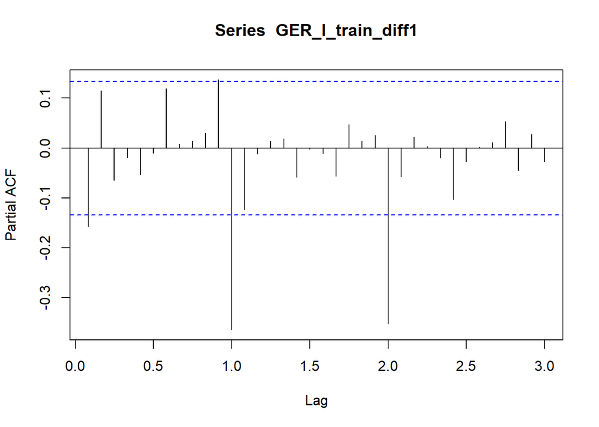

```r
pacf(GER_I_train_diff1, lag.max = 36)
```

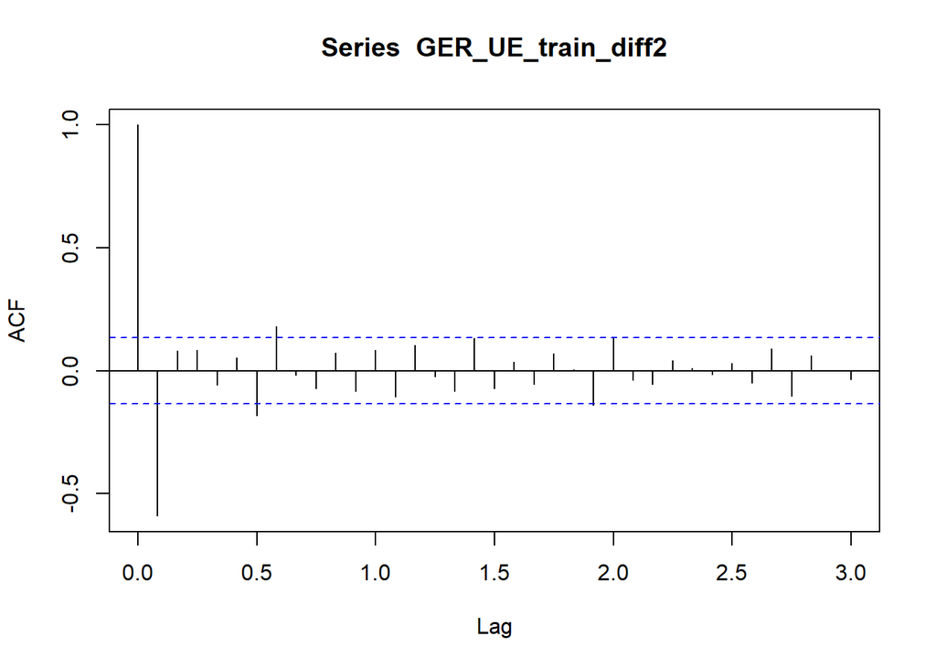

```r
acf(GER_UE_train_diff2, lag.max = 36)
```

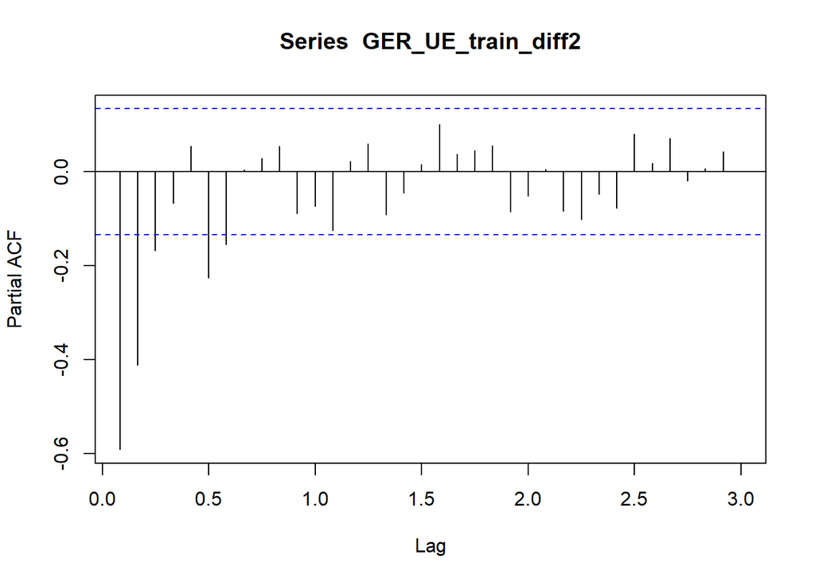

```r
pacf(GER_UE_train_diff2, lag.max = 36)
```

In the above plots for Inflation rate series of Germany we can see seasonal spikes so we will use SARIMA model but for Unemployment rate after Box-Cox transformation and second-order differencing there is no seasonal spikes in the ACF and PACF plots so we will use ARIMA model.

## Fitting the model

```r
# Fit SARIMA model

# 2 different models for Inflation rate in Germany

sarima_inflation_germany_1 <- Arima(GER_I_train,order = c(2,1,1),
                          seasonal = list(order = c(1,0,2), period = 12),
                          include.constant = FALSE)

sarima_inflation_germany_2 <- Arima(GER_I_train,order = c(2,1,1),
                          seasonal = list(order = c(2,0,1), period = 12),
                          include.constant = FALSE)


# 2 different models for Unemployment rate in Germany


arima_unemployment_germany_1 <- Arima(GER_UE_train,
                          order = c(2,2,3),
                          lambda="auto", include.constant = FALSE)


arima_unemployment_germany_2 <- Arima(GER_UE_train,
                          order = c(1,2,1),
                          lambda="auto", include.constant = FALSE)


# Check model summaries
cat("Summary of SARIMA Inflation Model 1:\n")
```

```
## Summary of SARIMA Inflation Model 1:
```

```r
summary(sarima_inflation_germany_1)
```

```
## Series: GER_I_train
## ARIMA(2,1,1)(1,0,2)[12]
##
## Coefficients:
##           ar1     ar2     ma1     sar1    sma1     sma2
##       -0.4881  0.0820  0.3560  -0.6897  0.0851  -0.6405
## s.e.   0.3639  0.1039  0.3633   0.1300  0.1245   0.0835
##
## sigma^2 = 0.05894:  log likelihood = -2.84
## AIC=19.68   AICc=20.22   BIC=43.28
##
## Training set error measures:
##                        ME      RMSE       MAE MPE MAPE     MASE         ACF1
## Training set -0.006507864 0.2388072 0.1880798 NaN  Inf 0.249261 -0.002725452
```

```r
cat("\n")
```

```r
cat("Summary of SARIMA Inflation Model 2:\n")
```

```
## Summary of SARIMA Inflation Model 2:
```

```r
summary(sarima_inflation_germany_2)
```

```
## Series: GER_I_train
## ARIMA(2,1,1)(2,0,1)[12]
##
## Coefficients:
##          ar1     ar2     ma1    sar1     sar2     sma1
##       -0.623  0.0309  0.4948  -0.192  -0.2452  -0.4652
## s.e.     NaN     NaN     NaN     NaN      NaN   0.0313
##
## sigma^2 = 0.0614:  log likelihood = -5.98
## AIC=25.95   AICc=26.5   BIC=49.55
##
## Training set error measures:
##                        ME      RMSE       MAE MPE MAPE     MASE        ACF1
## Training set -0.006485961 0.2437352 0.1936507 NaN  Inf 0.256644 0.005834219
```

```r
cat("\n")
```

```r
cat("Summary of ARIMA Unemployment Model 1:\n")
```

```
## Summary of ARIMA Unemployment Model 1:
```

```r
summary(arima_unemployment_germany_1)
```

```
## Series: GER_UE_train
## ARIMA(2,2,3)
## Box Cox transformation: lambda= -0.00761153
##
## Coefficients:
##          ar1      ar2      ma1     ma2      ma3
##       0.4428  -0.5835  -1.4316  1.3801  -0.6984
## s.e.  0.1328   0.0955   0.1220  0.0990   0.0616
##
## sigma^2 = 9.231e-05:  log likelihood = 692.06
## AIC=-1372.12   AICc=-1371.72   BIC=-1351.93
##
## Training set error measures:
##                       ME       RMSE        MAE          MPE      MAPE
## Training set -0.00177791 0.06684311 0.05247105 -0.008031858 0.7721407
##                    MASE      ACF1
## Training set 0.08006053 0.1443499
```

```r
cat("\n")
```

```r
cat("Summary of ARIMA Unemployment Model 2:\n")
```

```
## Summary of ARIMA Unemployment Model 2:
```

```r
summary(arima_unemployment_germany_2)
```

```
## Series: GER_UE_train
## ARIMA(1,2,1)
## Box Cox transformation: lambda= -0.00761153
##
## Coefficients:
##           ar1      ma1
##       -0.2533  -0.6846
## s.e.   0.0879   0.0724
##
## sigma^2 = 0.0001009:  log likelihood = 681.43
## AIC=-1356.86   AICc=-1356.74   BIC=-1346.76
##
## Training set error measures:
##                        ME       RMSE        MAE          MPE      MAPE
## Training set -0.001659747 0.06856901 0.05382985 -0.007259207 0.8086665
##                   MASE      ACF1
## Training set 0.0821338 0.1304238
```

```r
cat("\n")
```

Based on the AIC and BIC values, these are the chosen models:

For Germany Inflation Rate: sarima_inflation_germany_1 (ARIMA(2,1,1)(1,0,2)[12])

For Germany Unemployment Rate: arima_unemployment_germany_1 (ARIMA(2,2,3)) with Box Cox transformation

## Forecasting

```r
# Forecast for 24 months
forecast_inflation_germany <- forecast(sarima_inflation_germany_1, h=24)
forecast_unemployment_germany <- forecast(arima_unemployment_germany_1, h=24)

forecast_inflation_germany <- forecast_inflation_germany$mean
forecast_unemployment_germany <- forecast_unemployment_germany$mean
```

## Specifying the forecasted time period for the plot

```r
# Create a sequence of dates from January 2018 to December 2019
forecast_dates <- seq(as.Date("2018-01-01"), as.Date("2019-12-01"), by = "months")

# Convert the forecast dates to a decimal representation
forecast_time_decimal <- as.numeric(format(forecast_dates, "%Y")) +
                         as.numeric(format(forecast_dates, "%j")) / 365.25
```

## Plotting the forecasted and original data

### Inflation

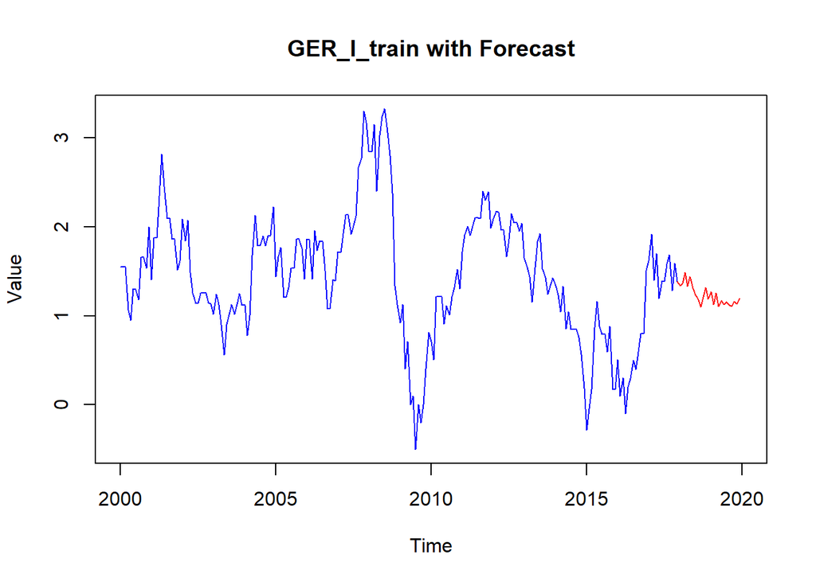

```r
# Plotting the original GER_I_train series
plot(GER_I_train, main = "GER_I_train with Forecast", ylab = "Value", col = "blue",
     xlim = c(2000, 2020))  # Set x-axis limits from 2000 to mid-2023

# Adding the forecasted values to the plot
lines(forecast_time_decimal, forecast_inflation_germany, col = "red")

# Connect the last actual data point to the first forecasted point
lines(c(time(GER_I_train)[length(GER_I_train)], forecast_time_decimal[1]),
      c(tail(GER_I_train, 1), forecast_inflation_germany[1]), col = "red")
```

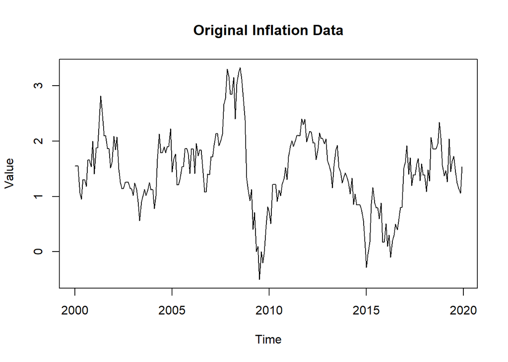

```r
# Plotting the original data
plot(GER_I_TS, main = "Original Inflation Data", xlab = "Time", ylab = "Value")
```

### Unemployment

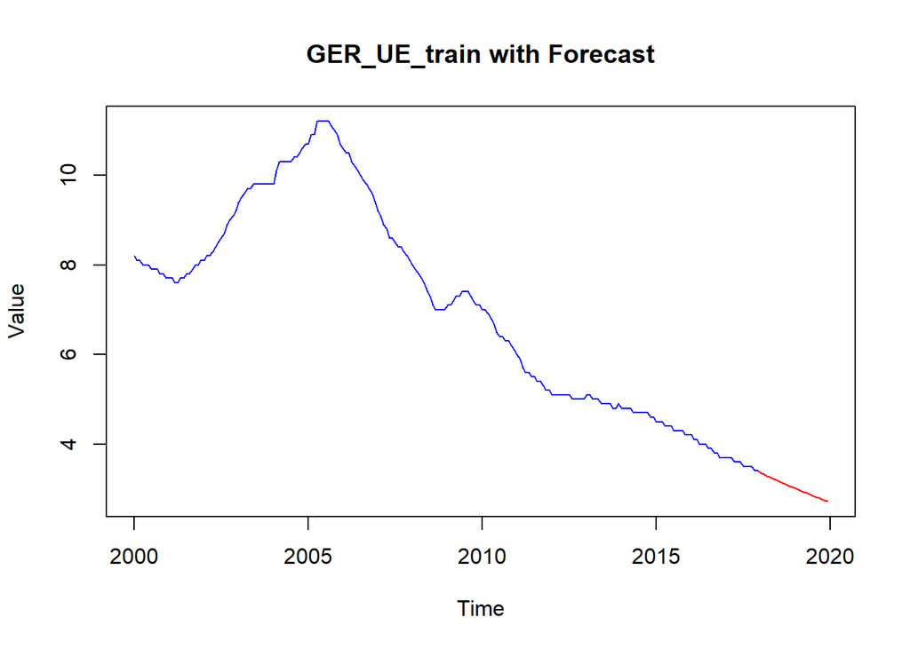

```r
# Plotting the original GER_UE_train series
plot(GER_UE_train, main = "GER_UE_train with Forecast", ylab = "Value", col = "blue",
     xlim = range(c(time(GER_UE_train), forecast_time_decimal)), # Dynamically set x-axis limits
     ylim = range(c(GER_UE_train, forecast_unemployment_germany))) # Set y-axis limits to include all values

# Adding the forecasted values to the plot
lines(forecast_time_decimal, forecast_unemployment_germany, col = "red")

# Connect the last actual data point to the first forecasted point
lines(c(tail(time(GER_UE_train), 1), forecast_time_decimal[1]),
      c(tail(GER_UE_train, 1), forecast_unemployment_germany[1]), col = "red")
```

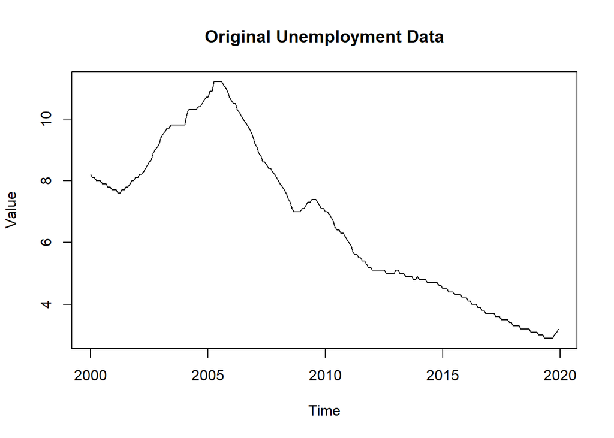

```r
# Plotting the original data
plot(GER_UE_TS, main = "Original Unemployment Data", xlab = "Time", ylab = "Value")
```

## Computing Different Metrics

### Inflation

```r
# Mean Absolute Error (MAE)
GER_I_mae <- mean(abs(GER_I_test - forecast_inflation_germany))

# Mean Squared Error (MSE)
GER_I_mse <- mean((GER_I_test - forecast_inflation_germany)^2)

# Root Mean Squared Error (RMSE)
GER_I_rmse <- sqrt(GER_I_mse)

# R-squared (R2) or Coefficient of Determination
GER_I_sst <- sum((GER_I_test - mean(GER_I_test))^2)
GER_I_ssr <- sum((GER_I_test - forecast_inflation_germany)^2)
GER_I_r2 <- 1 - (GER_I_ssr / GER_I_sst)

# Mean Absolute Percentage Error (MAPE)
GER_I_mape <- mean(abs((GER_I_test - forecast_inflation_germany) / GER_I_test)) * 100

# Printing those metrics

cat("Germany Inflation Rate \n\n")
```

```
## Germany Inflation Rate
```

```r
cat("Mean Absolute Error (MAE):", GER_I_mae, "\n")
```

```
## Mean Absolute Error (MAE): 0.3987676
```

```r
cat("Mean Squared Error (MSE):", GER_I_mse, "\n")
```

```
## Mean Squared Error (MSE): 0.2577975
```

```r
cat("Root Mean Squared Error (RMSE):", GER_I_rmse, "\n")
```

```
## Root Mean Squared Error (RMSE): 0.5077377
```

```r
cat("R-squared (R2):", GER_I_r2, "\n")
```

```
## R-squared (R2): -1.216039
```

```r
cat("Mean Absolute Percentage Error (MAPE):", GER_I_mape, "%\n")
```

```
## Mean Absolute Percentage Error (MAPE): 22.47607 %
```

### Unemployment

```r
# Mean Absolute Error (MAE)
GER_UE_mae <- mean(abs(GER_UE_test - forecast_unemployment_germany))

# Mean Squared Error (MSE)
GER_UE_mse <- mean((GER_UE_test - forecast_unemployment_germany)^2)

# Root Mean Squared Error (RMSE)
GER_UE_rmse <- sqrt(GER_UE_mse)

# R-squared (R2) or Coefficient of Determination
GER_UE_sst <- sum((GER_UE_test - mean(GER_UE_test))^2)
GER_UE_ssr <- sum((GER_UE_test - forecast_unemployment_germany)^2)
GER_UE_r2 <- 1 - (GER_UE_ssr / GER_UE_sst)

# Mean Absolute Percentage Error (MAPE)
GER_UE_mape <- mean(abs((GER_UE_test - forecast_unemployment_germany) / GER_UE_test)) * 100

# Printing those metrics

cat("Germany Unemployment rate \n\n")
```

```
## Germany Unemployment rate
```

```r
cat("Mean Absolute Error (MAE):", GER_UE_mae, "\n")
```

```
## Mean Absolute Error (MAE): 0.08182783
```

```r
cat("Mean Squared Error (MSE):", GER_UE_mse, "\n")
```

```
## Mean Squared Error (MSE): 0.01899471
```

```r
cat("Root Mean Squared Error (RMSE):", GER_UE_rmse, "\n")
```

```
## Root Mean Squared Error (RMSE): 0.1378213
```

```r
cat("R-squared (R2):", GER_UE_r2, "\n")
```

```
## R-squared (R2): 0.008971801
```

```r
cat("Mean Absolute Percentage Error (MAPE):", GER_UE_mape, "%\n")
```

```
## Mean Absolute Percentage Error (MAPE): 2.639 %
```

## Residual Checks

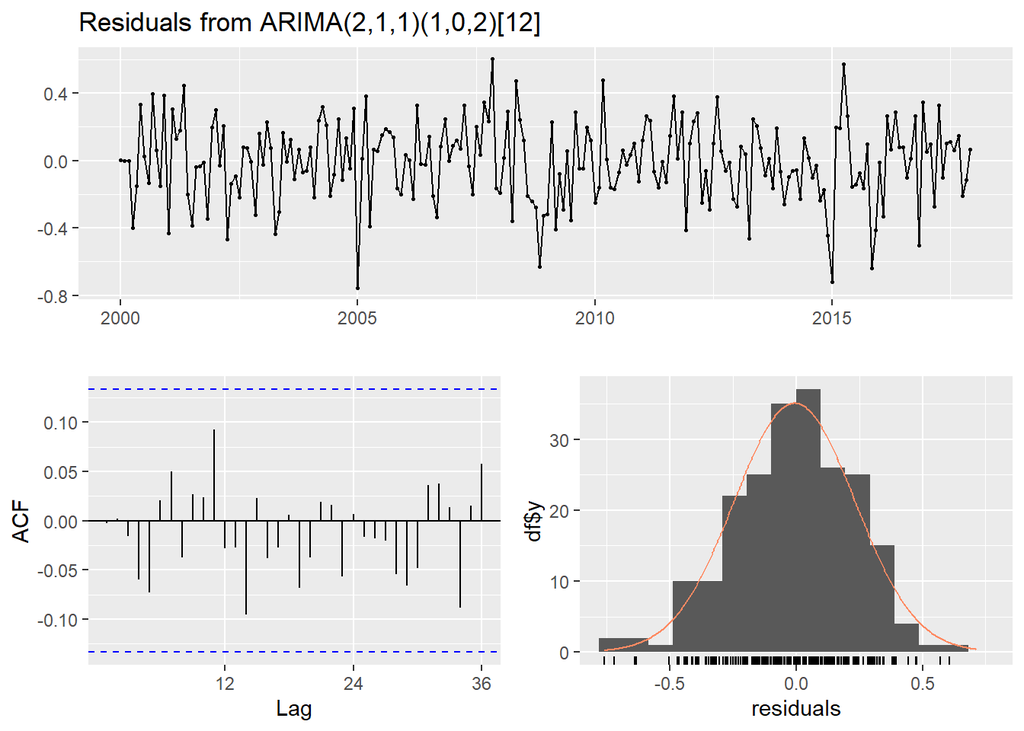

```
##
##  Ljung-Box test
##
## data:  Residuals from ARIMA(2,1,1)(1,0,2)[12]
## Q* = 10.787, df = 18, p-value = 0.9032
##
## Model df: 6.   Total lags used: 24
```

```r
# Check residuals of the inflation model
checkresiduals(sarima_inflation_germany_1)
```

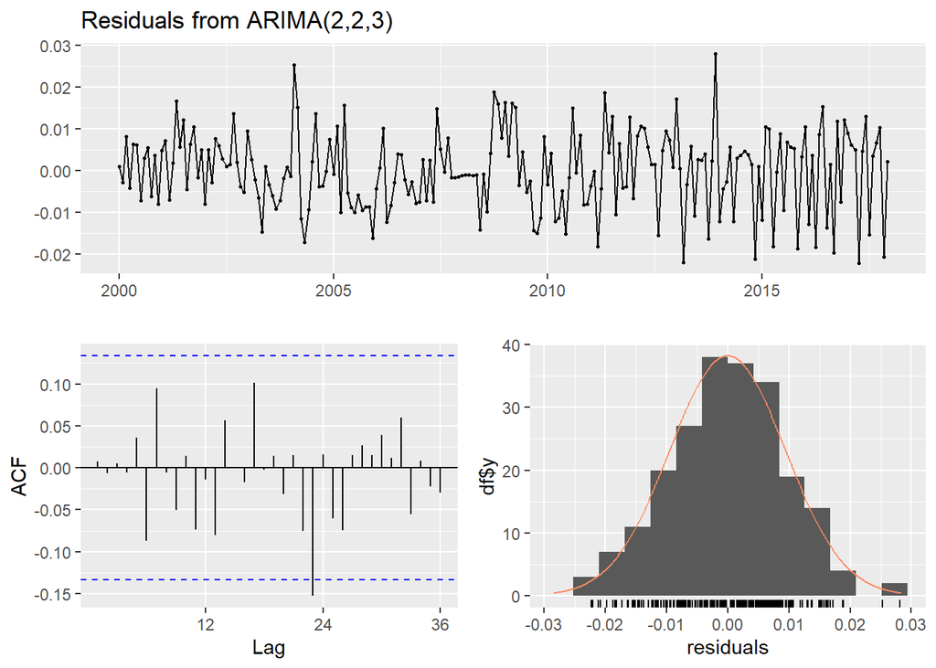

```
##
##  Ljung-Box test
##
## data:  Residuals from ARIMA(2,2,3)
## Q* = 18.123, df = 19, p-value = 0.5142
##
## Model df: 5.   Total lags used: 24
```

```r
# Check residuals of the unemployment model
checkresiduals(arima_unemployment_germany_1)
```

Based on the Ljung-Box test p-value for residuals from both models are higher than 0.05 which means that the residuals are independently distributed and the models are well-specified. The residuals are behaving like a white noise, indicating that the models have captured the underlying patterns in the data effectively.

# SPAIN

## Splitting the dataset

```r
# Inflation Data

# Create the training set
SPN_I_train <- window(SPN_I_TS, start=start_train, end=end_train)

# Create the test set
SPN_I_test <- window(SPN_I_TS, start=start_test, end=end_test)

# Unemployment Data

# Create the training set
SPN_UE_train <- window(SPN_UE_TS, start=start_train, end=end_train)

# Create the test set
SPN_UE_test <- window(SPN_UE_TS, start=start_test, end=end_test)
```

## Descriptive Statistics of the Data

```r
print("Spain Inflation Rate Data Summary:")
```

```
## [1] "Spain Inflation Rate Data Summary:"
```

```r
summary(SPN_I_train)
```

```
##    Min. 1st Qu.  Median    Mean 3rd Qu.    Max.
##  -1.369   1.317   2.630   2.201   3.470   5.274
```

```r
cat("\n")
```

```r
print("Spain Unemployment Rate Data Summary:")
```

```
## [1] "Spain Unemployment Rate Data Summary:"
```

```r
summary(SPN_UE_train)
```

```
##    Min. 1st Qu.  Median    Mean 3rd Qu.    Max.
##    7.90   10.70   15.35   15.94   20.82   26.40
```

## Plotting Histogram

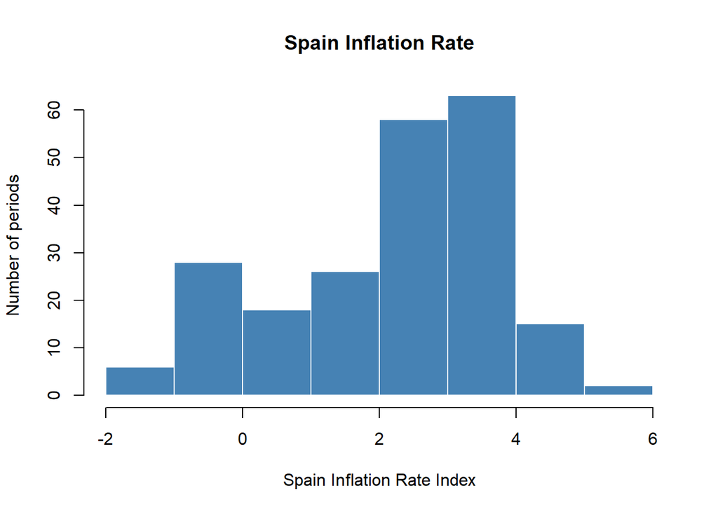

```r
# Inflation Germany
hist(SPN_I_train,col='steelblue', border = "white", xlab = 'Spain Inflation Rate Index', ylab = 'Number of periods', main = 'Spain Inflation Rate')
```

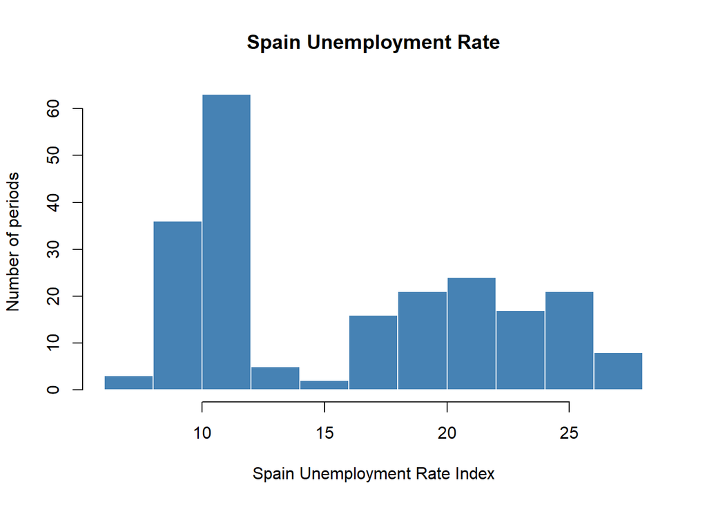

```r
# Unemployment Germany
hist(SPN_UE_train,col='steelblue', border = "white", xlab = 'Spain Unemployment Rate Index', ylab = 'Number of periods', main = 'Spain Unemployment Rate')
```

## Time Series Decomposition

```r
SPN_I_train_decomposed <- decompose(SPN_I_train)
SPN_UE_train_decomposed <- decompose(SPN_UE_train)
```

## Plot the decomposed series

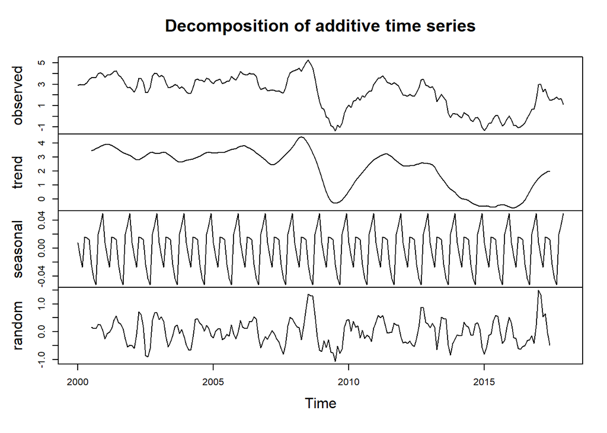

```r
plot(SPN_I_train_decomposed)
```

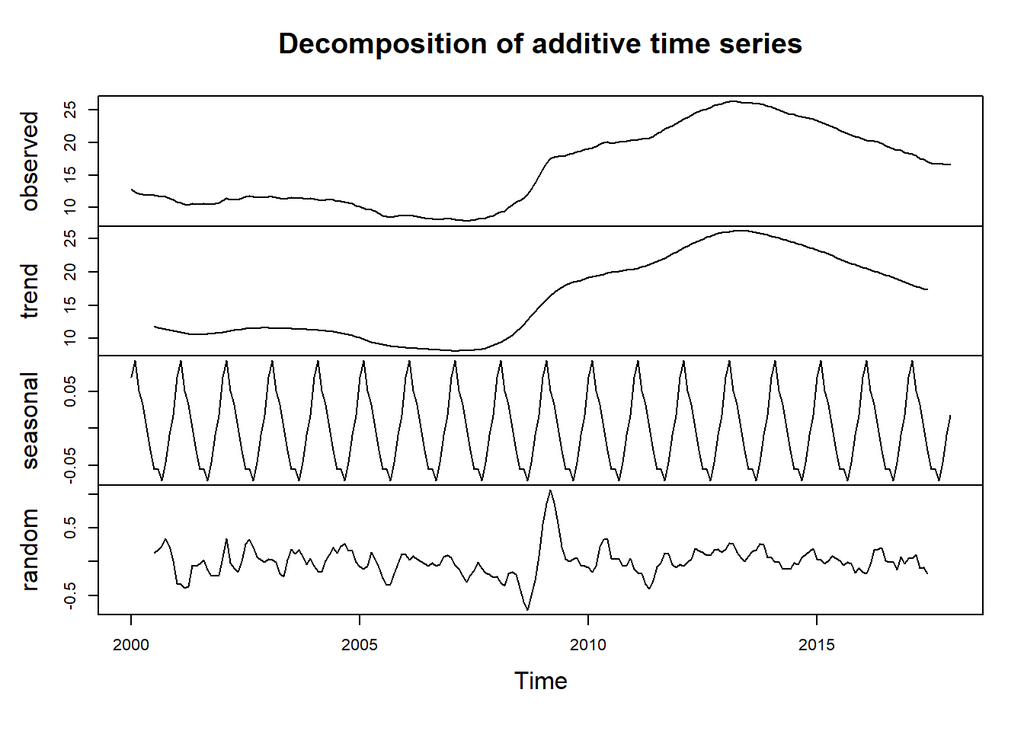

```r
plot(SPN_UE_train_decomposed)
```

## Box-Cox Transformation

```r
BoxCox.lambda(SPN_I_train)
```

```
## [1] 1.086723
```

For Spain Inflation series, we do not need to apply box-cox transformation as the lambda value is close to 1.

```r
BoxCox.lambda(SPN_UE_train)
```

```
## [1] 1.29099
```

For Spain Unemployment series, we will apply box-cox transformation.

```r
lambda_spn_ue <- 1.29099
SPN_UE_train_BoxCox <- BoxCox(SPN_UE_train, lambda = lambda_spn_ue)
```

## Stationarity Check

### ADF Test

```r
# Augmented Dickey-Fuller Test
adf.test(SPN_I_train)
```

```
##
##  Augmented Dickey-Fuller Test
##
## data:  SPN_I_train
## Dickey-Fuller = -4.0501, Lag order = 5, p-value = 0.01
## alternative hypothesis: stationary
```

```r
adf.test(SPN_UE_train_BoxCox)
```

```
##
##  Augmented Dickey-Fuller Test
##
## data:  SPN_UE_train_BoxCox
## Dickey-Fuller = -1.7806, Lag order = 5, p-value = 0.668
## alternative hypothesis: stationary
```

### KPSS Test

```r
# KPSS Test
kpss.test(SPN_I_train)
```

```
##
##  KPSS Test for Level Stationarity
##
## data:  SPN_I_train
## KPSS Level = 2.0914, Truncation lag parameter = 4, p-value = 0.01
```

```r
kpss.test(SPN_UE_train_BoxCox)
```

```
##
##  KPSS Test for Level Stationarity
##
## data:  SPN_UE_train_BoxCox
## KPSS Level = 3.0808, Truncation lag parameter = 4, p-value = 0.01
```

## Result of ADF and KPSS Test

SPN_I_train (Spain Inflation Rate Training Set)

- ADF Test: p-value = smaller than 0.01
- KPSS Test: p-value = smaller than 0.01

SPN_UE_train_BoxCox (Spain Unemployment Rate Training Set)

- ADF Test: p-value = 0.668
- KPSS Test: p-value = smaller than 0.01

So, based on these results:

- For SPN_I_train as well,ADF test suggests stationarity but KPSS test suggests non-stationarity. So, we apply first-order differencing to make the series consistently stationary.
- For SPN_UE_train_BoxCox, both tests show non-stationarity. We definitely have to apply differencing to this series.

## First-Order Differences

```r
SPN_I_train_diff1 <- diff(SPN_I_train)
SPN_UE_train_diff1 <- diff(SPN_UE_train_BoxCox)
```

## Stationarity Check Again

### ADF Test on the First-Order Differenced Series

```r
adf.test(SPN_I_train_diff1)
```

```
##
##  Augmented Dickey-Fuller Test
##
## data:  SPN_I_train_diff1
## Dickey-Fuller = -5.1955, Lag order = 5, p-value = 0.01
## alternative hypothesis: stationary
```

```r
adf.test(SPN_UE_train_diff1)
```

```
##
##  Augmented Dickey-Fuller Test
##
## data:  SPN_UE_train_diff1
## Dickey-Fuller = -2.4584, Lag order = 5, p-value = 0.3837
## alternative hypothesis: stationary
```

### KPSS Test on the First-Order Differenced Series

```r
# KPSS Test
kpss.test(SPN_I_train_diff1)
```

```
##
##  KPSS Test for Level Stationarity
##
## data:  SPN_I_train_diff1
## KPSS Level = 0.034199, Truncation lag parameter = 4, p-value = 0.1
```

```r
kpss.test(SPN_UE_train_diff1)
```

```
##
##  KPSS Test for Level Stationarity
##
## data:  SPN_UE_train_diff1
## KPSS Level = 0.57397, Truncation lag parameter = 4, p-value = 0.02501
```

## Result of ADF and KPSS Test on First-Order Differenced Series

SPN_I_train (Spain Inflation Rate Training Set)

- ADF Test: p-value = smaller than 0.01
- KPSS Test: p-value = greater than 0.1

SPN_UE_train (Spain Unemployment Rate Training Set)

- ADF Test: p-value = 0.3837
- KPSS Test: p-value = 0.02501

So, based on these results:

- For SPN_I_train_diff1, both tests show stationarity. So, no further differencing required.
- For SPN_UE_train_diff1, both tests show that the series is still non-stationary even after first-order differencing. So, we can further apply second-order differencing for this series.

## Second-Order Differencing

```r
SPN_UE_train_diff2 <- diff(SPN_UE_train_diff1)
```

## Stationarity Check for Unemployment Series

### ADF Test on the Second-Order Differenced Series

```r
adf.test(SPN_UE_train_diff2)
```

```
##
##  Augmented Dickey-Fuller Test
##
## data:  SPN_UE_train_diff2
## Dickey-Fuller = -7.4157, Lag order = 5, p-value = 0.01
## alternative hypothesis: stationary
```

### KPSS Test on the Second-Order Differenced Series

```r
# KPSS Test
kpss.test(SPN_UE_train_diff2)
```

```
##
##  KPSS Test for Level Stationarity
##
## data:  SPN_UE_train_diff2
## KPSS Level = 0.054319, Truncation lag parameter = 4, p-value = 0.1
```

## Result of ADF and KPSS Test on Second-Order Differenced Series for Unemployment Data

SPN_UE_train (Spain Unemployment Rate Training Set)

- ADF Test: p-value = smaller than 0.01
- KPSS Test: p-value = greater than 0.1

Based on these results, SPN_UE_train_diff2 is stationary.

## Autocorrelation Function and Partial-Autocorrelation Function (ACF & PACF)

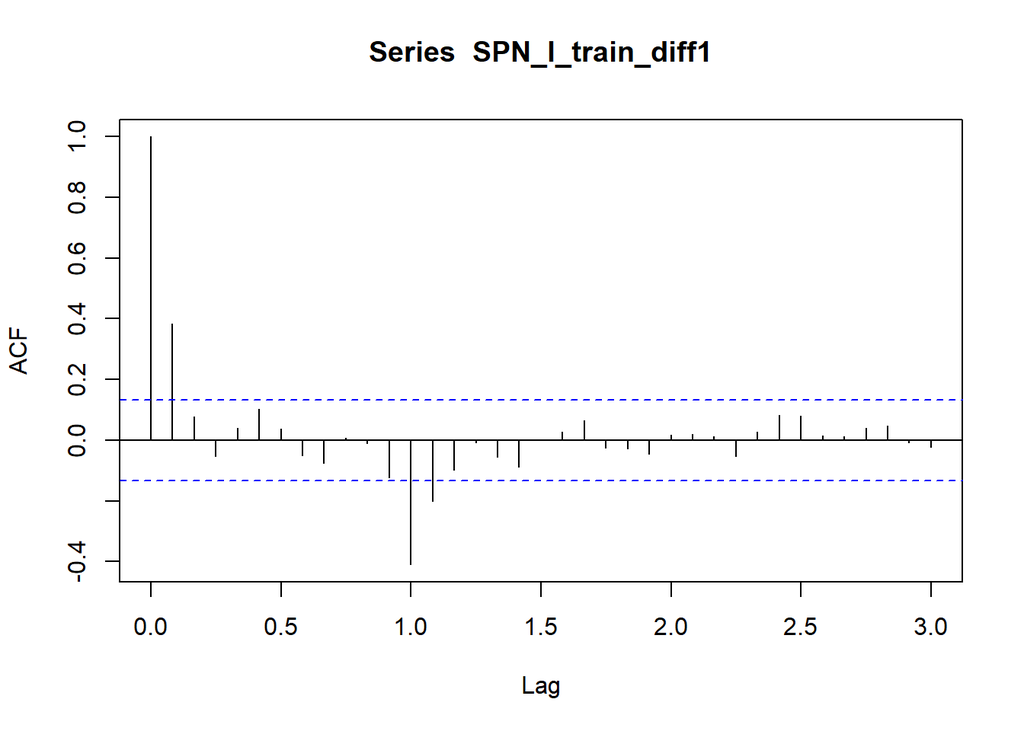

```r
acf(SPN_I_train_diff1, lag.max = 36)
```

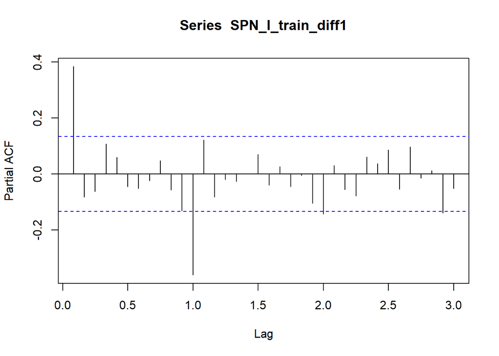

```r
pacf(SPN_I_train_diff1, lag.max = 36)
```

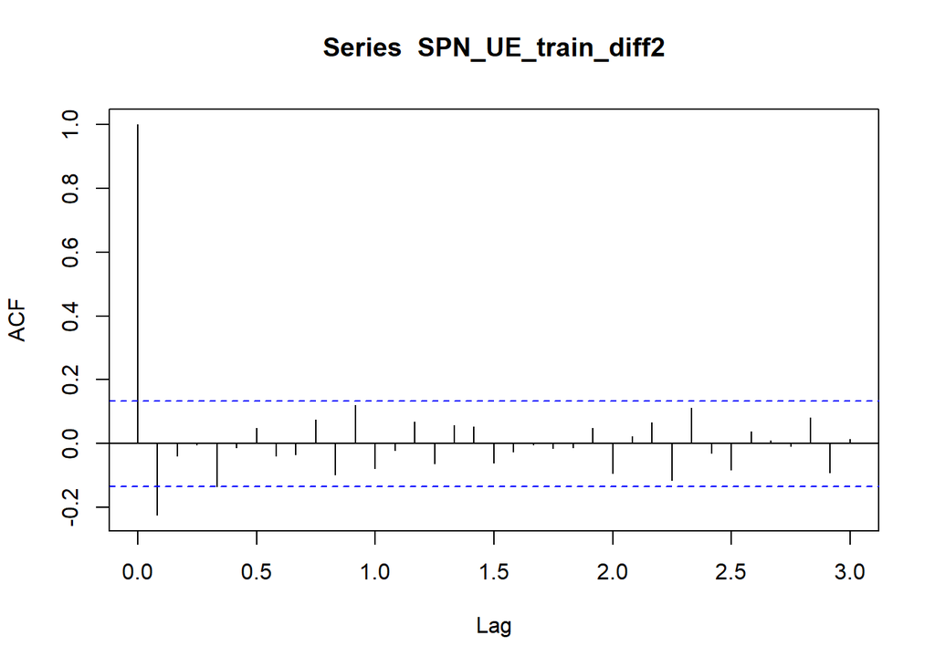

```r
acf(SPN_UE_train_diff2, lag.max = 36)
```

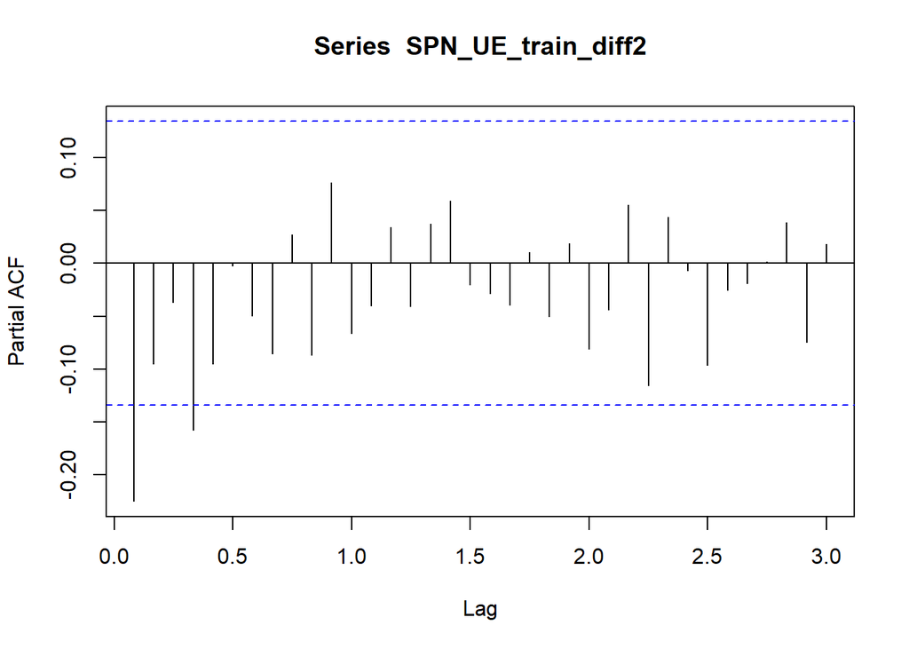

```r
pacf(SPN_UE_train_diff2, lag.max = 36)
```

In the above plots for Inflation rate series of Spain we can see seasonal spikes so we will use SARIMA model but for Unemployment rate after Box-Cox transformation and second-order differencing there is no seasonal spikes in the ACF and PACF plots so we will use ARIMA model.

## Fitting the model

```r
# Fit SARIMA model

# 2 different models for Inflation rate in Spain

sarima_inflation_spain_1 <- Arima(SPN_I_train,order = c(2,1,2),
                          seasonal = list(order = c(0,0,1), period = 12),
                          include.constant = FALSE)

sarima_inflation_spain_2 <- Arima(SPN_I_train,order = c(1,1,2),
                          seasonal = list(order = c(1,0,1), period = 12),
                          include.constant = FALSE)


# 2 different models for Unemployment rate in Spain


arima_unemployment_spain_1 <- Arima(SPN_UE_train,
                          order = c(1,2,0),
                          lambda="auto", include.constant = FALSE)


arima_unemployment_spain_2 <- Arima(SPN_UE_train,
                          order = c(1,2,1),
                          lambda="auto", include.constant = FALSE)


# Check model summaries
cat("Summary of SARIMA Inflation Model 1:\n")
```

```
## Summary of SARIMA Inflation Model 1:
```

```r
summary(sarima_inflation_spain_1)
```

```
## Series: SPN_I_train
## ARIMA(2,1,2)(0,0,1)[12]
##
## Coefficients:
##          ar1      ar2      ma1     ma2     sma1
##       0.5611  -0.5601  -0.1626  0.4431  -0.6672
## s.e.  0.2017   0.1453   0.2186  0.1313   0.0651
##
## sigma^2 = 0.09039:  log likelihood = -47.87
## AIC=107.73   AICc=108.14   BIC=127.96
##
## Training set error measures:
##                       ME      RMSE       MAE       MPE     MAPE     MASE
## Training set -0.02223857 0.2964502 0.2333113 -3.461545 39.02408 0.165797
##                     ACF1
## Training set 0.003445367
```

```r
cat("\n")
```

```r
cat("Summary of SARIMA Inflation Model 2:\n")
```

```
## Summary of SARIMA Inflation Model 2:
```

```r
summary(sarima_inflation_spain_2)
```

```
## Series: SPN_I_train
## ARIMA(1,1,2)(1,0,1)[12]
##
## Coefficients:
##           ar1     ma1     ma2    sar1     sma1
##       -0.3605  0.7885  0.3122  0.0590  -0.6758
## s.e.   0.3199  0.3003  0.0988  0.1286   0.1126
##
## sigma^2 = 0.09273:  log likelihood = -50.21
## AIC=112.42   AICc=112.82   BIC=132.64
##
## Training set error measures:
##                       ME      RMSE       MAE       MPE     MAPE      MASE
## Training set -0.01771804 0.3002583 0.2346381 -2.947471 34.81062 0.1667399
##                      ACF1
## Training set -0.009640829
```

```r
cat("\n")
```

```r
cat("Summary of ARIMA Unemployment Model 1:\n")
```

```
## Summary of ARIMA Unemployment Model 1:
```

```r
summary(arima_unemployment_spain_1)
```

```
## Series: SPN_UE_train
## ARIMA(1,2,0)
## Box Cox transformation: lambda= 1.291003
##
## Coefficients:
##           ar1
##       -0.2261
## s.e.   0.0668
##
## sigma^2 = 0.09297:  log likelihood = -49
## AIC=102   AICc=102.06   BIC=108.73
##
## Training set error measures:
##                       ME      RMSE       MAE      MPE      MAPE       MASE
## Training set 0.003497763 0.1389575 0.1058377 0.056287 0.7738839 0.05502264
##                     ACF1
## Training set -0.02202152
```

```r
cat("\n")
```

```r
cat("Summary of ARIMA Unemployment Model 2:\n")
```

```
## Summary of ARIMA Unemployment Model 2:
```

```r
summary(arima_unemployment_spain_2)
```

```
## Series: SPN_UE_train
## ARIMA(1,2,1)
## Box Cox transformation: lambda= 1.291003
##
## Coefficients:
##          ar1      ma1
##       0.5646  -0.8195
## s.e.  0.1452   0.1066
##
## sigma^2 = 0.08994:  log likelihood = -45.05
## AIC=96.11   AICc=96.22   BIC=106.21
##
## Training set error measures:
##                       ME      RMSE     MAE        MPE      MAPE       MASE
## Training set 0.004913051 0.1362441 0.10453 0.08378125 0.7678002 0.05434281
##                     ACF1
## Training set -0.03400512
```

```r
cat("\n")
```

Based on the AIC and BIC values, these are the chosen models:

For Spain Inflation Rate: sarima_inflation_spain_1 (ARIMA(2,1,2)(0,0,1)[12])

For Spain Unemployment Rate: arima_unemployment_spain_2 (ARIMA(1,2,1)) with Box Cox transformation

## Forecasting

```r
# Forecast for 24 months
forecast_inflation_spain <- forecast(sarima_inflation_spain_1, h=24)
forecast_unemployment_spain <- forecast(arima_unemployment_spain_2, h=24)

forecast_inflation_spain <- forecast_inflation_spain$mean
forecast_unemployment_spain <- forecast_unemployment_spain$mean
```

## Plotting the forecasted and original data

### Inflation

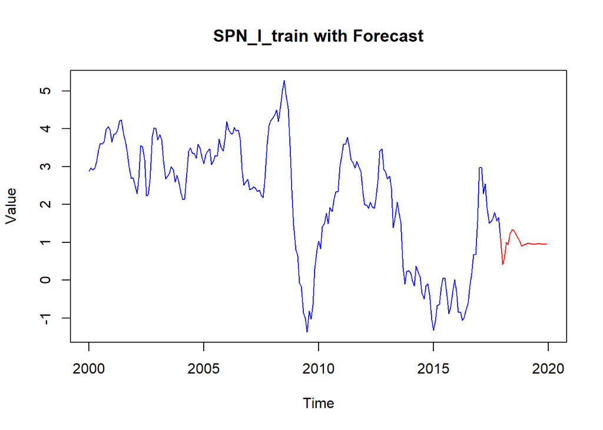

```r
# Plotting the original SPN_I_train series
plot(SPN_I_train, main = "SPN_I_train with Forecast", ylab = "Value", col = "blue",
     xlim = c(2000, 2020))  # Set x-axis limits from 2000 to mid-2023

# Adding the forecasted values to the plot
lines(forecast_time_decimal, forecast_inflation_spain, col = "red")

# Connect the last actual data point to the first forecasted point
lines(c(time(SPN_I_train)[length(SPN_I_train)], forecast_time_decimal[1]),
      c(tail(SPN_I_train, 1), forecast_inflation_spain[1]), col = "red")
```

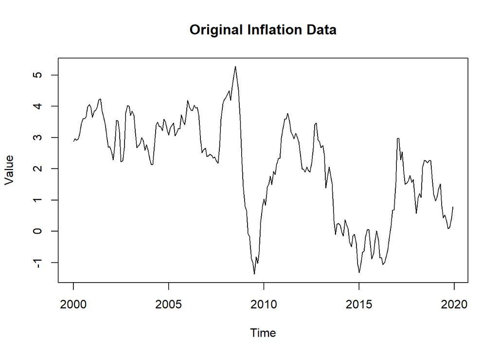

```r
# Plotting the original data
plot(SPN_I_TS, main = "Original Inflation Data", xlab = "Time", ylab = "Value")
```

### Unemployment

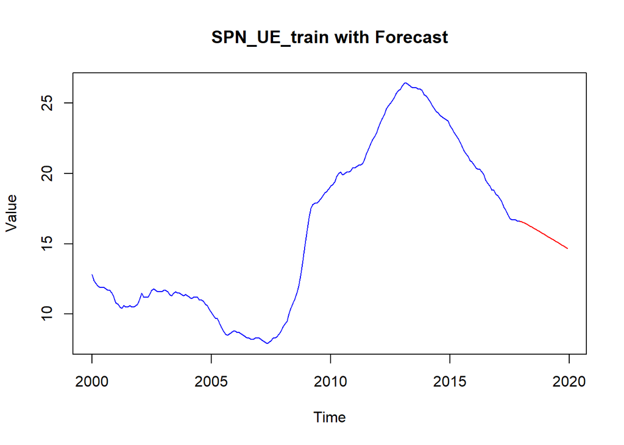

```r
# Plotting the original SPN_UE_train series
plot(SPN_UE_train, main = "SPN_UE_train with Forecast", ylab = "Value", col = "blue",
     xlim = range(c(time(SPN_UE_train), forecast_time_decimal)), # Dynamically set x-axis limits
     ylim = range(c(SPN_UE_train, forecast_unemployment_spain))) # Set y-axis limits to include all values

# Adding the forecasted values to the plot
lines(forecast_time_decimal, forecast_unemployment_spain, col = "red")

# Connect the last actual data point to the first forecasted point
lines(c(tail(time(SPN_UE_train), 1), forecast_time_decimal[1]),
      c(tail(SPN_UE_train, 1), forecast_unemployment_spain[1]), col = "red")
```

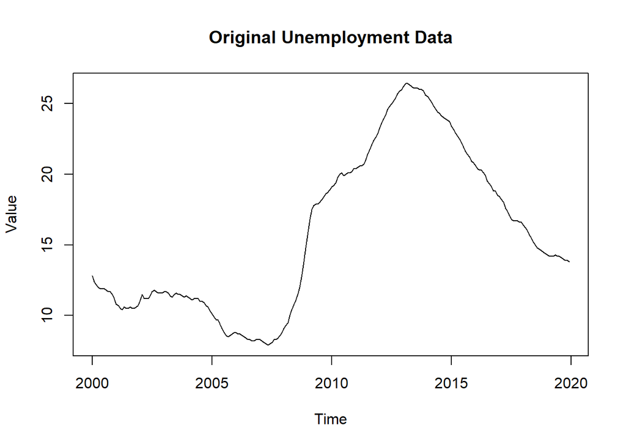

```r
# Plotting the original data
plot(SPN_UE_TS, main = "Original Unemployment Data", xlab = "Time", ylab = "Value")
```

## Computing Different Metrics

### Inflation

```r
# Mean Absolute Error (MAE)
SPN_I_mae <- mean(abs(SPN_I_test - forecast_inflation_spain))

# Mean Squared Error (MSE)
SPN_I_mse <- mean((SPN_I_test - forecast_inflation_spain)^2)

# Root Mean Squared Error (RMSE)
SPN_I_rmse <- sqrt(SPN_I_mse)

# R-squared (R2) or Coefficient of Determination
SPN_I_sst <- sum((SPN_I_test - mean(SPN_I_test))^2)
SPN_I_ssr <- sum((SPN_I_test - forecast_inflation_spain)^2)
SPN_I_r2 <- 1 - (SPN_I_ssr / SPN_I_sst)

# Mean Absolute Percentage Error (MAPE)
SPN_I_mape <- mean(abs((SPN_I_test - forecast_inflation_spain) / SPN_I_test)) * 100

# Printing those metrics

cat("Spain Inflation Rate \n\n")
```

```
## Spain Inflation Rate
```

```r
cat("Mean Absolute Error (MAE):", SPN_I_mae, "\n")
```

```
## Mean Absolute Error (MAE): 0.5549362
```

```r
cat("Mean Squared Error (MSE):", SPN_I_mse, "\n")
```

```
## Mean Squared Error (MSE): 0.4302736
```

```r
cat("Root Mean Squared Error (RMSE):", SPN_I_rmse, "\n")
```

```
## Root Mean Squared Error (RMSE): 0.6559524
```

```r
cat("R-squared (R2):", SPN_I_r2, "\n")
```

```
## R-squared (R2): 0.1529913
```

```r
cat("Mean Absolute Percentage Error (MAPE):", SPN_I_mape, "%\n")
```

```
## Mean Absolute Percentage Error (MAPE): 116.0183 %
```

### Unemployment

```r
# Mean Absolute Error (MAE)
SPN_UE_mae <- mean(abs(SPN_UE_test - forecast_unemployment_spain))

# Mean Squared Error (MSE)
SPN_UE_mse <- mean((SPN_UE_test - forecast_unemployment_spain)^2)

# Root Mean Squared Error (RMSE)
SPN_UE_rmse <- sqrt(SPN_UE_mse)

# R-squared (R2) or Coefficient of Determination
SPN_UE_sst <- sum((SPN_UE_test - mean(SPN_UE_test))^2)
SPN_UE_ssr <- sum((SPN_UE_test - forecast_unemployment_spain)^2)
SPN_UE_r2 <- 1 - (SPN_UE_ssr / SPN_UE_sst)

# Mean Absolute Percentage Error (MAPE)
SPN_UE_mape <- mean(abs((SPN_UE_test - forecast_unemployment_spain) / SPN_UE_test)) * 100

# Printing those metrics

cat("Spain Unemployment rate \n\n")
```

```
## Spain Unemployment rate
```

```r
cat("Mean Absolute Error (MAE):", SPN_UE_mae, "\n")
```

```
## Mean Absolute Error (MAE): 0.9689466
```

```r
cat("Mean Squared Error (MSE):", SPN_UE_mse, "\n")
```

```
## Mean Squared Error (MSE): 1.037372
```

```r
cat("Root Mean Squared Error (RMSE):", SPN_UE_rmse, "\n")
```

```
## Root Mean Squared Error (RMSE): 1.018515
```

```r
cat("R-squared (R2):", SPN_UE_r2, "\n")
```

```
## R-squared (R2): -0.8497556
```

```r
cat("Mean Absolute Percentage Error (MAPE):", SPN_UE_mape, "%\n")
```

```
## Mean Absolute Percentage Error (MAPE): 6.686231 %
```

## Residual Checks

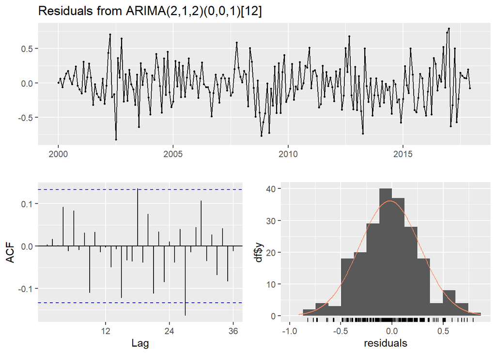

```
##
##  Ljung-Box test
##
## data:  Residuals from ARIMA(2,1,2)(0,0,1)[12]
## Q* = 22.819, df = 19, p-value = 0.2454
##
## Model df: 5.   Total lags used: 24
```

```r
# Check residuals of the inflation model
checkresiduals(sarima_inflation_spain_1)
```

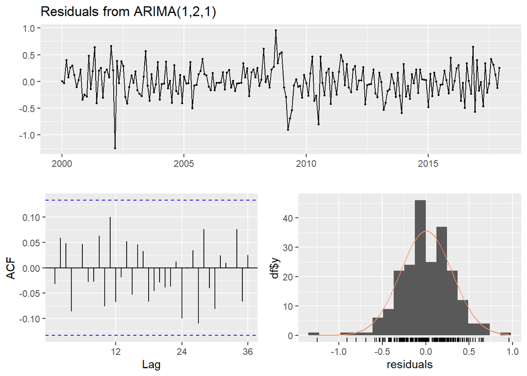

```
##
##  Ljung-Box test
##
## data:  Residuals from ARIMA(1,2,1)
## Q* = 16.699, df = 22, p-value = 0.7798
##
## Model df: 2.   Total lags used: 24
```

```r
# Check residuals of the unemployment model
checkresiduals(arima_unemployment_spain_2)
```

Based on the Ljung-Box test p-value for residuals from both models are higher than 0.05 which means that the residuals are independently distributed and the models are well-specified. The residuals are behaving like a white noise, indicating that the models have captured the underlying patterns in the data effectively.

# PORTUGAL

## Splitting the dataset

```r
# Inflation Data

# Create the training set
POR_I_train <- window(POR_I_TS, start=start_train, end=end_train)

# Create the test set
POR_I_test <- window(POR_I_TS, start=start_test, end=end_test)

# Unemployment Data

# Create the training set
POR_UE_train <- window(POR_UE_TS, start=start_train, end=end_train)

# Create the test set
POR_UE_test <- window(POR_UE_TS, start=start_test, end=end_test)
```

## Descriptive Statistics of the Data

```r
print("Portugal Inflation Rate Data Summary:")
```

```
## [1] "Portugal Inflation Rate Data Summary:"
```

```r
summary(POR_I_train)
```

```
##    Min. 1st Qu.  Median    Mean 3rd Qu.    Max.
##  -1.665   0.724   2.346   2.017   3.149   5.117
```

```r
cat("\n")
```

```r
print("Portugal Unemployment Rate Data Summary:")
```

```
## [1] "Portugal Unemployment Rate Data Summary:"
```

```r
summary(POR_UE_train)
```

```
##    Min. 1st Qu.  Median    Mean 3rd Qu.    Max.
##   5.000   8.175   9.700  10.550  12.800  18.200
```

## Plotting Histogram

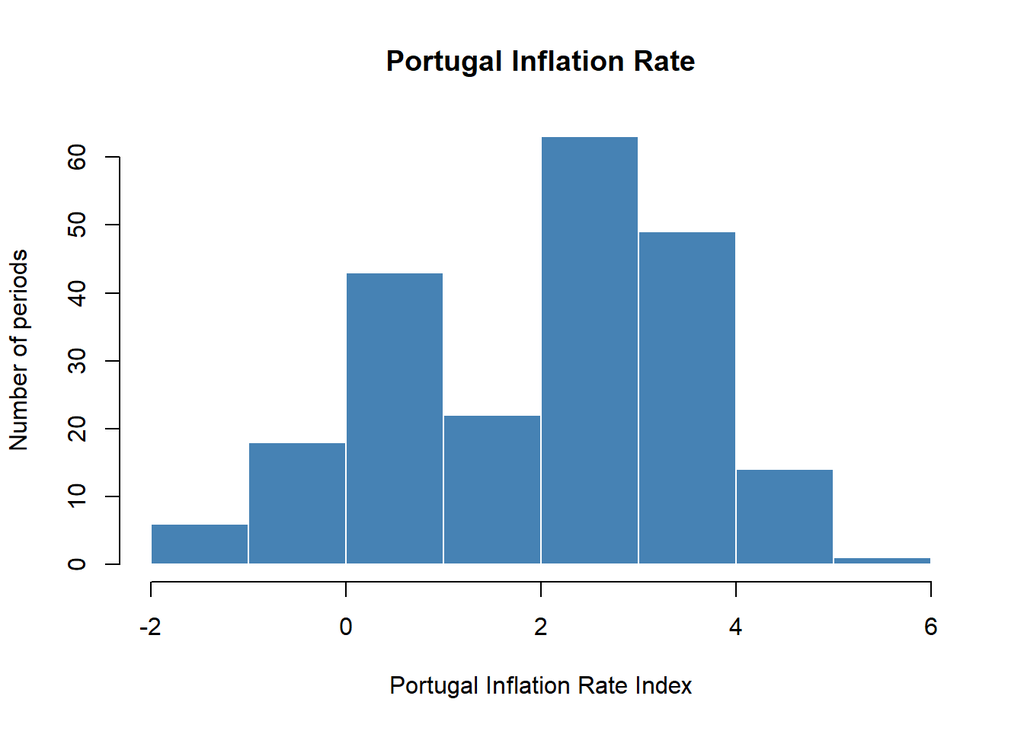

```r
# Inflation Portugal
hist(POR_I_train,col='steelblue', border = "white", xlab = 'Portugal Inflation Rate Index', ylab = 'Number of periods', main = 'Portugal Inflation Rate')
```

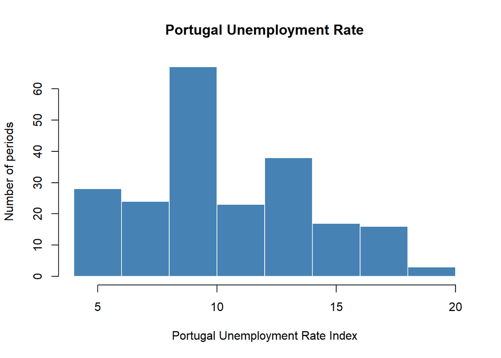

```r
# Unemployment Portugal
hist(POR_UE_train,col='steelblue', border = "white", xlab = 'Portugal Unemployment Rate Index', ylab = 'Number of periods', main = 'Portugal Unemployment Rate')
```

## Time Series Decomposition

```r
POR_I_train_decomposed <- decompose(POR_I_train)
POR_UE_train_decomposed <- decompose(POR_UE_train)
```

## Plot the decomposed series

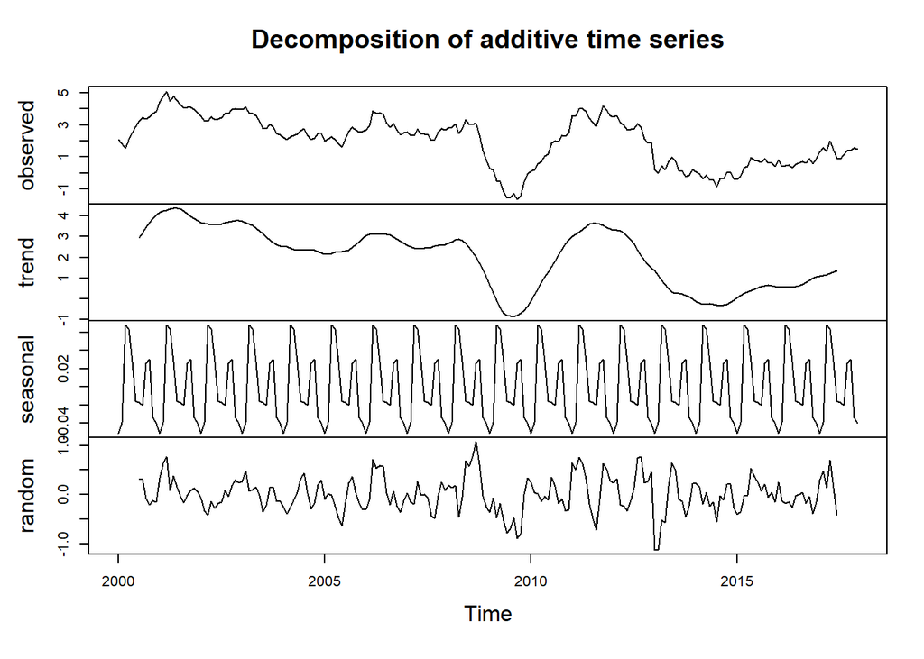

```r
plot(POR_I_train_decomposed)
```

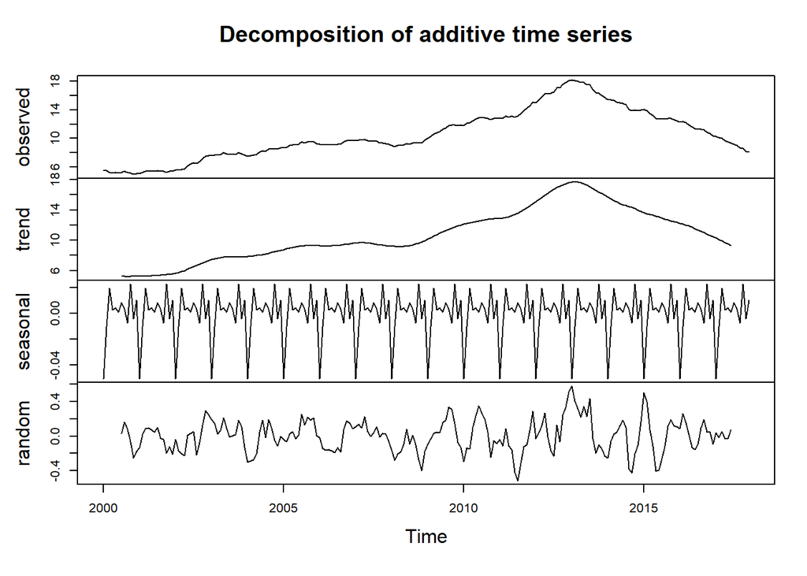

```r
plot(POR_UE_train_decomposed)
```

## Box-Cox Transformation

```r
BoxCox.lambda(POR_I_train)
```

```
## [1] 0.8705989
```

```r
BoxCox.lambda(POR_UE_train)
```

```
## [1] 0.3550989
```

```r
lambda_por_i <- 0.8705989
POR_I_train_BoxCox <- BoxCox(POR_I_train, lambda = lambda_por_i)

lambda_por_ue <- 0.3550989
POR_UE_train_BoxCox <- BoxCox(POR_UE_train, lambda = lambda_por_ue)
```

## Stationarity Check

### ADF Test

```r
# Augmented Dickey-Fuller Test
adf.test(POR_I_train_BoxCox)
```

```
##
##  Augmented Dickey-Fuller Test
##
## data:  POR_I_train_BoxCox
## Dickey-Fuller = -2.7957, Lag order = 5, p-value = 0.2422
## alternative hypothesis: stationary
```

```r
adf.test(POR_UE_train_BoxCox)
```

```
##
##  Augmented Dickey-Fuller Test
##
## data:  POR_UE_train_BoxCox
## Dickey-Fuller = 0.4887, Lag order = 5, p-value = 0.99
## alternative hypothesis: stationary
```

### KPSS Test

```r
# KPSS Test
kpss.test(POR_I_train_BoxCox)
```

```
##
##  KPSS Test for Level Stationarity
##
## data:  POR_I_train_BoxCox
## KPSS Level = 1.8773, Truncation lag parameter = 4, p-value = 0.01
```

```r
kpss.test(POR_UE_train_BoxCox)
```

```
##
##  KPSS Test for Level Stationarity
##
## data:  POR_UE_train_BoxCox
## KPSS Level = 3.1419, Truncation lag parameter = 4, p-value = 0.01
```

## Result of ADF and KPSS Test

POR_I_train_BoxCox (Portugal Inflation Rate Training Set)

- ADF Test: p-value = 0.2422
- KPSS Test: p-value = smaller than 0.01

POR_UE_train_BoxCox (Portugal Unemployment Rate Training Set)

- ADF Test: p-value = 0.99
- KPSS Test: p-value = smaller than 0.01

So, based on these results:

- For POR_I_train_BoxCox, both tests show non-stationarity. So, we have to apply differencing to this series.
- For POR_UE_train_BoxCox as well, both tests show non-stationarity. We definitely have to apply differencing to this series.

## First-Order Differences

```r
POR_I_train_diff1 <- diff(POR_I_train_BoxCox)
POR_UE_train_diff1 <- diff(POR_UE_train_BoxCox)
```

## Stationarity Check Again

### ADF Test on the First-Order Differenced Series

```r
adf.test(POR_I_train_diff1)
```

```
##
##  Augmented Dickey-Fuller Test
##
## data:  POR_I_train_diff1
## Dickey-Fuller = -4.8841, Lag order = 5, p-value = 0.01
## alternative hypothesis: stationary
```

```r
adf.test(POR_UE_train_diff1)
```

```
##
##  Augmented Dickey-Fuller Test
##
## data:  POR_UE_train_diff1
## Dickey-Fuller = -3.4381, Lag order = 5, p-value = 0.04969
## alternative hypothesis: stationary
```

### KPSS Test on the First-Order Differenced Series

```r
# KPSS Test
kpss.test(POR_I_train_diff1)
```

```
##
##  KPSS Test for Level Stationarity
##
## data:  POR_I_train_diff1
## KPSS Level = 0.052679, Truncation lag parameter = 4, p-value = 0.1
```

```r
kpss.test(POR_UE_train_diff1)
```

```
##
##  KPSS Test for Level Stationarity
##
## data:  POR_UE_train_diff1
## KPSS Level = 1.0739, Truncation lag parameter = 4, p-value = 0.01
```

## Result of ADF and KPSS Test on First-Order Differenced Series

POR_I_train (Portugal Inflation Rate Training Set)

- ADF Test: p-value = smaller than 0.01
- KPSS Test: p-value = greater than 0.1

POR_UE_train (Portugal Unemployment Rate Training Set)

- ADF Test: p-value = 0.04969
- KPSS Test: p-value = smaller than 0.01

So, based on these results:

- For POR_I_train_diff1, both tests show stationarity. So, no further differencing required.
- For POR_UE_train_diff1, ADF test suggests a borderline case but still allowing for the rejection of the null hypothesis of non-stationarity. But KPSS test still indicates non-stationarity. So, we can further apply second-order differencing for this series.

## Second-Order Differencing

```r
POR_UE_train_diff2 <- diff(POR_UE_train_diff1)
```

## Stationarity Check for Unemployment Series

### ADF Test on the Second-Order Differenced Series

```r
adf.test(POR_UE_train_diff2)
```

```
##
##  Augmented Dickey-Fuller Test
##
## data:  POR_UE_train_diff2
## Dickey-Fuller = -9.6995, Lag order = 5, p-value = 0.01
## alternative hypothesis: stationary
```

### KPSS Test on the Second-Order Differenced Series

```r
# KPSS Test
kpss.test(POR_UE_train_diff2)
```

```
##
##  KPSS Test for Level Stationarity
##
## data:  POR_UE_train_diff2
## KPSS Level = 0.026728, Truncation lag parameter = 4, p-value = 0.1
```

## Result of ADF and KPSS Test on Second-Order Differenced Series for Unemployment Data

POR_UE_train (Portugal Unemployment Rate Training Set)

- ADF Test: p-value = smaller than 0.01
- KPSS Test: p-value = greater than 0.1

Based on these results, POR_UE_train_diff2 is stationary.

## Autocorrelation Function and Partial-Autocorrelation Function (ACF & PACF)

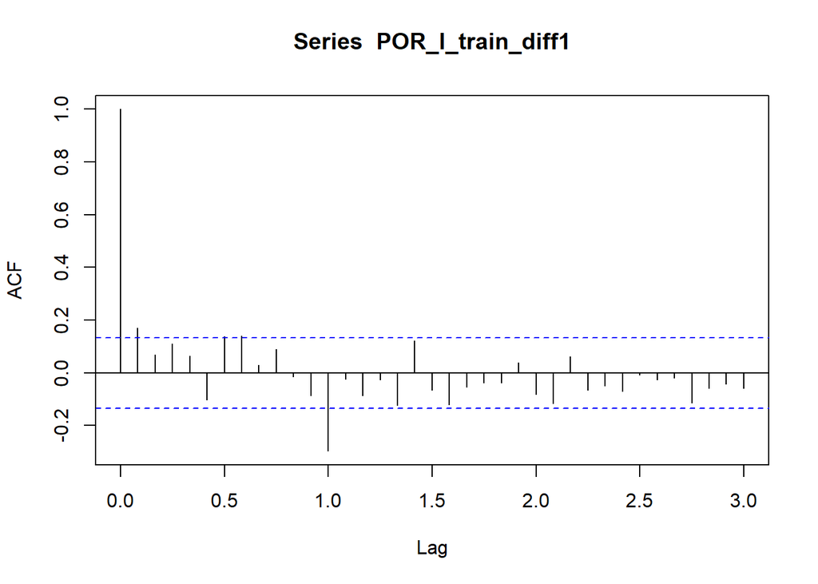

```r
acf(POR_I_train_diff1, lag.max = 36)
```

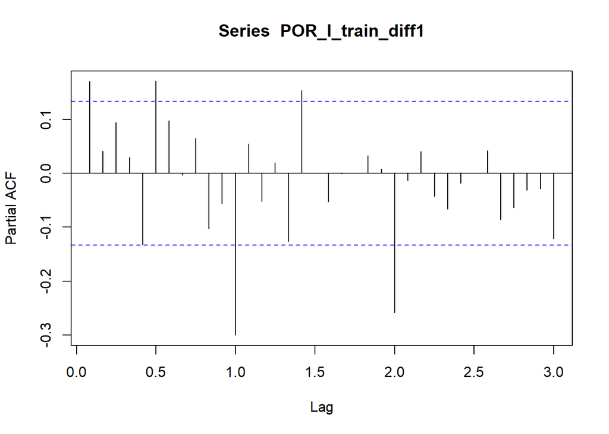

```r
pacf(POR_I_train_diff1, lag.max = 36)
```

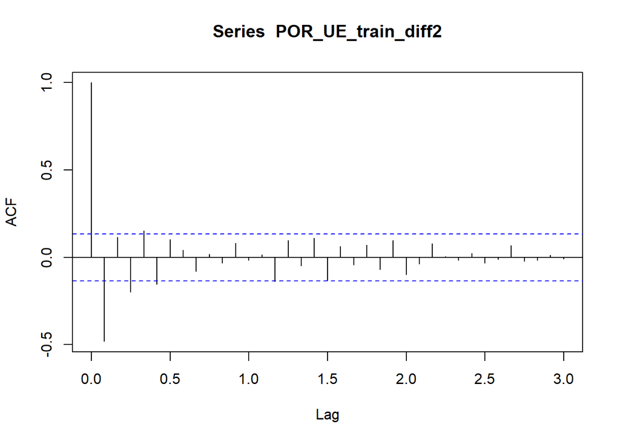

```r
acf(POR_UE_train_diff2, lag.max = 36)
```

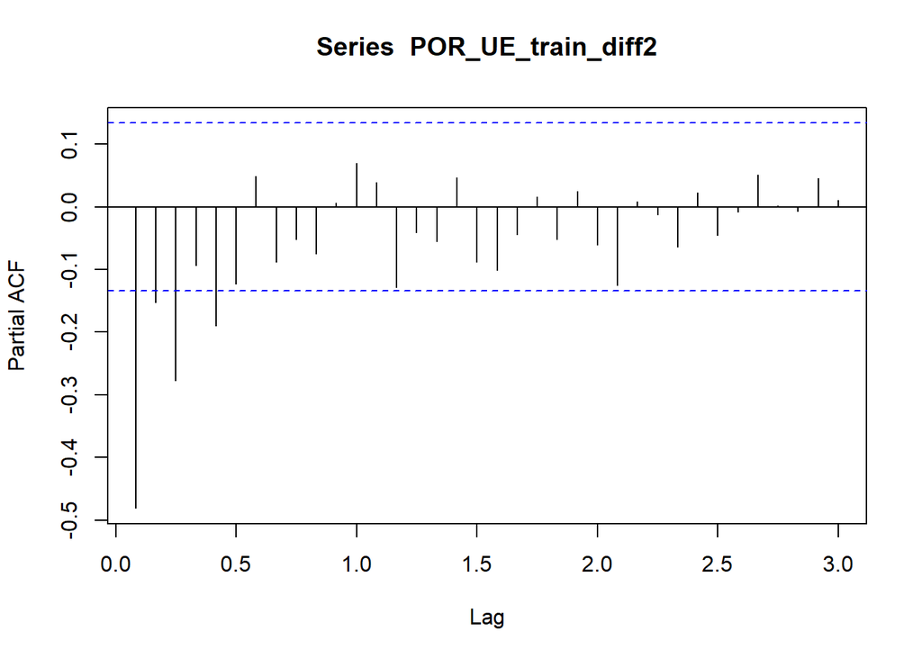

```r
pacf(POR_UE_train_diff2, lag.max = 36)
```

In the above plots for Inflation rate series of Portugal we can see seasonal spikes so we will use SARIMA model but for Unemployment rate after Box-Cox transformation and second-order differencing there is no seasonal spikes in the ACF and PACF plots so we will use ARIMA model.

## Fitting the model

```r
# Fit SARIMA model

# 2 different models for Inflation rate in Portugal

sarima_inflation_portugal_1 <- Arima(POR_I_train,order =
                          c(6,1,0),
                          seasonal = list(order = c(0,0,1),
                          period = 12),
                          lambda = "auto",
                          include.constant = FALSE)

sarima_inflation_portugal_2 <- Arima(POR_I_train,order =
                          c(0,1,1),
                          seasonal = list(order = c(0,0,2),
                          period = 12), lambda = "auto",
                          include.constant = FALSE)

# 2 different models for Unemployment rate in Portugal


arima_unemployment_portugal_1 <- Arima(POR_UE_train,
                          order = c(2,2,2),
                          lambda="auto", include.constant = FALSE)


arima_unemployment_portugal_2 <- Arima(POR_UE_train,
                          order = c(1,2,2),
                          lambda="auto", include.constant = FALSE)

# Check model summaries
cat("Summary of SARIMA Inflation Model 1:\n")
```

```
## Summary of SARIMA Inflation Model 1:
```

```r
summary(sarima_inflation_portugal_1)
```

```
## Series: POR_I_train
## ARIMA(6,1,0)(0,0,1)[12]
## Box Cox transformation: lambda= 0.8705989
##
## Coefficients:
##          ar1      ar2     ar3      ar4      ar5     ar6     sma1
##       0.1630  -0.0349  0.1222  -0.0561  -0.0371  0.2425  -0.5864
## s.e.  0.0661   0.0690  0.0669   0.0685   0.0693  0.0692   0.0740
##
## sigma^2 = 0.08855:  log likelihood = -43.47
## AIC=102.93   AICc=103.63   BIC=129.9
##
## Training set error measures:
##                        ME      RMSE       MAE        MPE     MAPE      MASE
## Training set -0.008217038 0.2996988 0.2211594 -0.8147406 47.96995 0.1817566
##                    ACF1
## Training set 0.01517256
```

```r
cat("\n")
```

```r
cat("Summary of SARIMA Inflation Model 2:\n")
```

```
## Summary of SARIMA Inflation Model 2:
```

```r
summary(sarima_inflation_portugal_2)
```

```
## Series: POR_I_train
## ARIMA(0,1,1)(0,0,2)[12]
## Box Cox transformation: lambda= 0.8705989
##
## Coefficients:
##          ma1     sma1     sma2
##       0.1602  -0.4435  -0.1339
## s.e.  0.0707   0.0680   0.0648
##
## sigma^2 = 0.09272:  log likelihood = -49.96
## AIC=107.93   AICc=108.12   BIC=121.41
##
## Training set error measures:
##                       ME      RMSE       MAE      MPE     MAPE      MASE
## Training set -0.01193741 0.3092765 0.2273128 3.185875 50.48502 0.1868136
##                     ACF1
## Training set 0.009149372
```

```r
cat("\n")
```

```r
cat("Summary of ARIMA Unemployment Model 1:\n")
```

```
## Summary of ARIMA Unemployment Model 1:
```

```r
summary(arima_unemployment_portugal_1)
```

```
## Series: POR_UE_train
## ARIMA(2,2,2)
## Box Cox transformation: lambda= 0.3551033
##
## Coefficients:
##           ar1     ar2      ma1      ma2
##       -0.4072  0.2762  -0.2760  -0.5207
## s.e.   0.2025  0.1022   0.1939   0.1381
##
## sigma^2 = 0.001286:  log likelihood = 410.11
## AIC=-810.22   AICc=-809.93   BIC=-793.39
##
## Training set error measures:
##                        ME      RMSE       MAE          MPE     MAPE       MASE
## Training set -0.007357753 0.1628328 0.1263941 -0.005607295 1.251674 0.09686096
##                    ACF1
## Training set 0.01536896
```

```r
cat("\n")
```

```r
cat("Summary of ARIMA Unemployment Model 2:\n")
```

```
## Summary of ARIMA Unemployment Model 2:
```

```r
summary(arima_unemployment_portugal_2)
```

```
## Series: POR_UE_train
## ARIMA(1,2,2)
## Box Cox transformation: lambda= 0.3551033
##
## Coefficients:
##           ar1     ma1      ma2
##       -0.8130  0.0522  -0.5402
## s.e.   0.1383  0.1530   0.1239
##
## sigma^2 = 0.001322:  log likelihood = 406.77
## AIC=-805.54   AICc=-805.35   BIC=-792.07
##
## Training set error measures:
##                        ME      RMSE      MAE           MPE     MAPE       MASE
## Training set -0.005569418 0.1646292 0.129728 -0.0001647314 1.293385 0.09941588
##                   ACF1
## Training set 0.0899064
```

```r
cat("\n")
```

For Portugal Unemployment Rate: arima_unemployment_portugal_1 (ARIMA(2,2,2)) with Box Cox transformation.

## Forecasting

```r
# Forecast for 24 months
forecast_inflation_portugal <- forecast(sarima_inflation_portugal_1, h=24)
forecast_unemployment_portugal <- forecast(arima_unemployment_portugal_1, h=24)

forecast_inflation_portugal <- forecast_inflation_portugal$mean
forecast_unemployment_portugal <- forecast_unemployment_portugal$mean
```

## Plotting the forecasted and original data

### Inflation

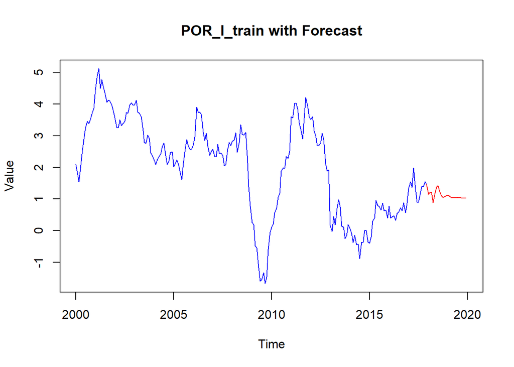

```r
# Plotting the original POR_I_train series
plot(POR_I_train, main = "POR_I_train with Forecast", ylab = "Value", col = "blue",
     xlim = c(2000, 2020))  # Set x-axis limits from 2000 to mid-2023

# Adding the forecasted values to the plot
lines(forecast_time_decimal, forecast_inflation_portugal, col = "red")

# Connect the last actual data point to the first forecasted point
lines(c(time(POR_I_train)[length(POR_I_train)], forecast_time_decimal[1]),
      c(tail(POR_I_train, 1), forecast_inflation_portugal[1]), col = "red")
```

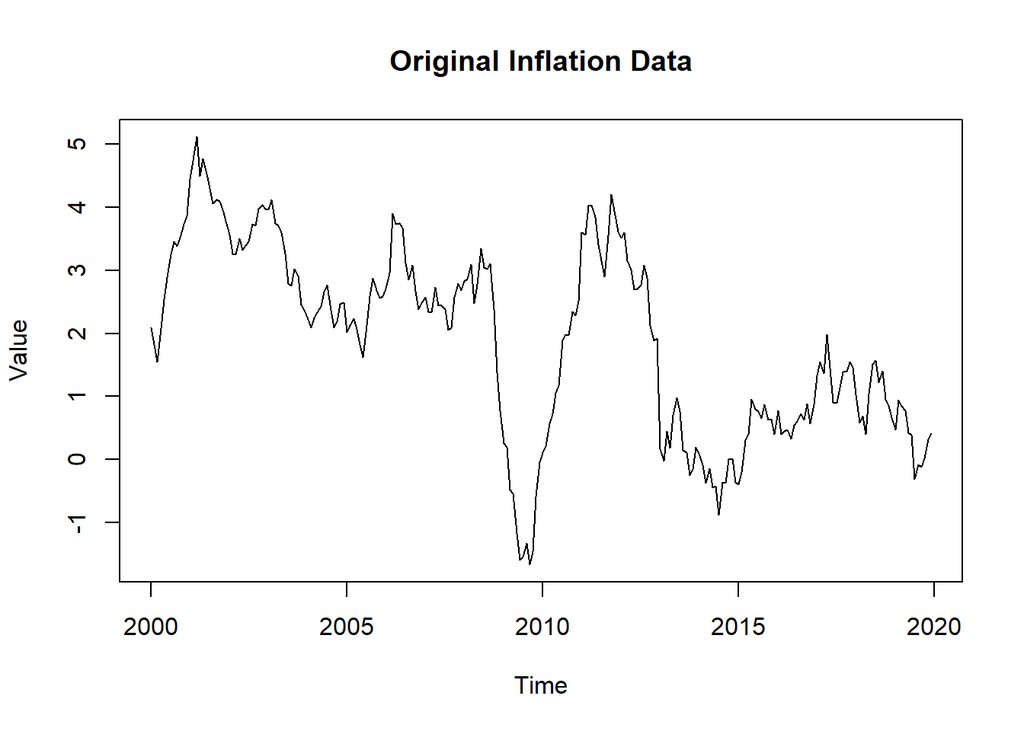

```r
# Plotting the original data
plot(POR_I_TS, main = "Original Inflation Data", xlab = "Time", ylab = "Value")
```

### Unemployment

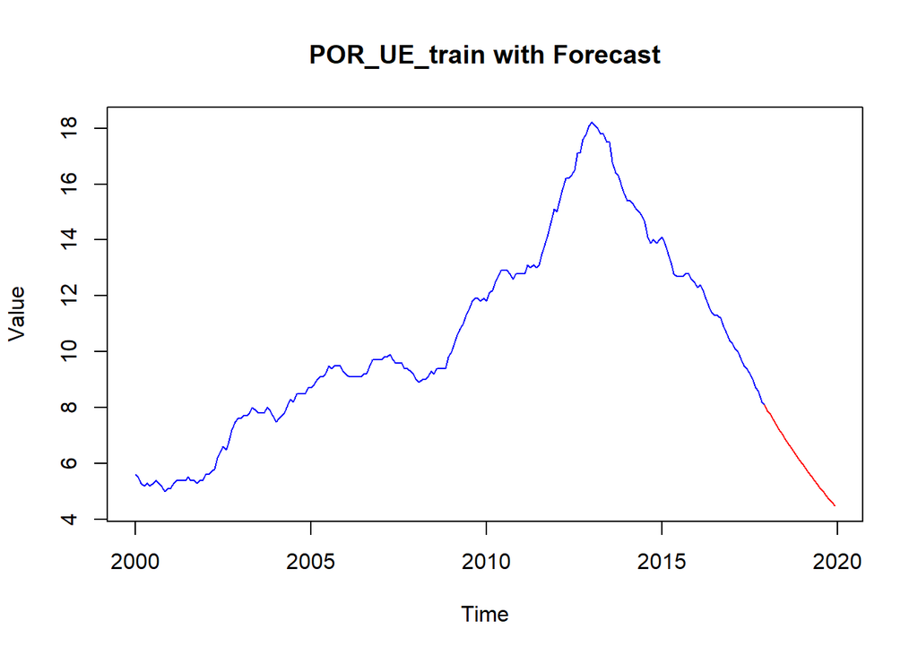

```r
# Plotting the original POR_UE_train series
plot(POR_UE_train, main = "POR_UE_train with Forecast", ylab = "Value", col = "blue",
     xlim = range(c(time(POR_UE_train), forecast_time_decimal)), # Dynamically set x-axis limits
     ylim = range(c(POR_UE_train, forecast_unemployment_portugal))) # Set y-axis limits to include all values

# Adding the forecasted values to the plot
lines(forecast_time_decimal, forecast_unemployment_portugal, col = "red")

# Connect the last actual data point to the first forecasted point
lines(c(tail(time(POR_UE_train), 1), forecast_time_decimal[1]),
      c(tail(POR_UE_train, 1), forecast_unemployment_portugal[1]), col = "red")
```

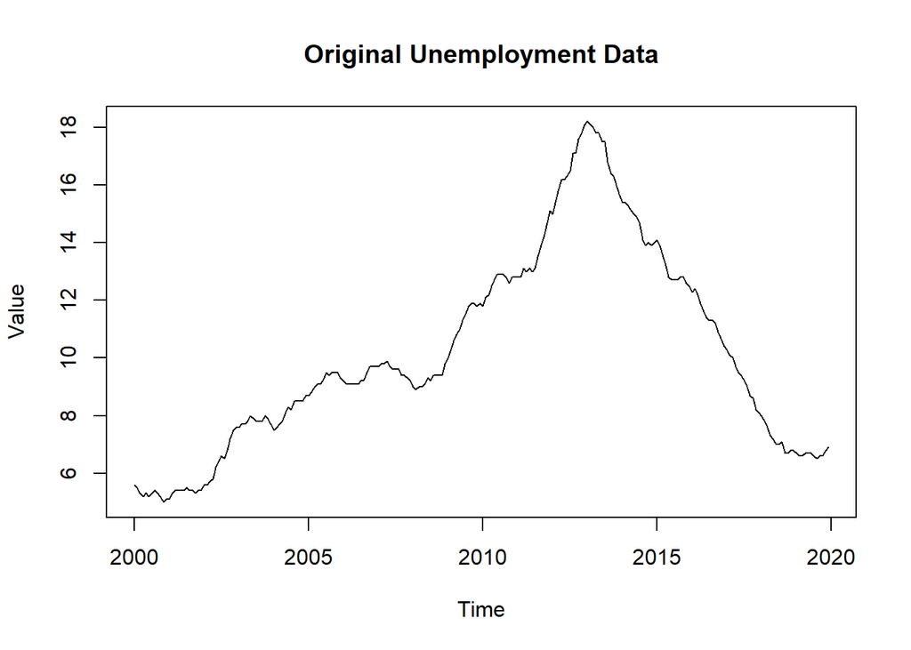

```r
# Plotting the original data
plot(POR_UE_TS, main = "Original Unemployment Data", xlab = "Time", ylab = "Value")
```

## Computing Different Metrics

### Inflation

```r
# Mean Absolute Error (MAE)
POR_I_mae <- mean(abs(POR_I_test - forecast_inflation_portugal))

# Mean Squared Error (MSE)
POR_I_mse <- mean((POR_I_test - forecast_inflation_portugal)^2)

# Root Mean Squared Error (RMSE)
POR_I_rmse <- sqrt(POR_I_mse)

# R-squared (R2) or Coefficient of Determination
POR_I_sst <- sum((POR_I_test - mean(POR_I_test))^2)
POR_I_ssr <- sum((POR_I_test - forecast_inflation_portugal)^2)
POR_I_r2 <- 1 - (POR_I_ssr / POR_I_sst)

# Mean Absolute Percentage Error (MAPE)
POR_I_mape <- mean(abs((POR_I_test - forecast_inflation_portugal) / POR_I_test)) * 100

# Printing those metrics

cat("Portugal Inflation Rate \n\n")
```

```
## Portugal Inflation Rate
```

```r
cat("Mean Absolute Error (MAE):", POR_I_mae, "\n")
```

```
## Mean Absolute Error (MAE): 0.4907029
```

```r
cat("Mean Squared Error (MSE):", POR_I_mse, "\n")
```

```
## Mean Squared Error (MSE): 0.3788038
```

```r
cat("Root Mean Squared Error (RMSE):", POR_I_rmse, "\n")
```

```
## Root Mean Squared Error (RMSE): 0.6154704
```

```r
cat("R-squared (R2):", POR_I_r2, "\n")
```

```
## R-squared (R2): -0.5407272
```

```r
cat("Mean Absolute Percentage Error (MAPE):", POR_I_mape, "%\n")
```

```
## Mean Absolute Percentage Error (MAPE): 450.0512 %
```

### Unemployment

```r
# Mean Absolute Error (MAE)
POR_UE_mae <- mean(abs(POR_UE_test - forecast_unemployment_portugal))

# Mean Squared Error (MSE)
POR_UE_mse <- mean((POR_UE_test - forecast_unemployment_portugal)^2)

# Root Mean Squared Error (RMSE)
POR_UE_rmse <- sqrt(POR_UE_mse)

# R-squared (R2) or Coefficient of Determination
POR_UE_sst <- sum((POR_UE_test - mean(POR_UE_test))^2)
POR_UE_ssr <- sum((POR_UE_test - forecast_unemployment_portugal)^2)
POR_UE_r2 <- 1 - (POR_UE_ssr / POR_UE_sst)

# Mean Absolute Percentage Error (MAPE)
POR_UE_mape <- mean(abs((POR_UE_test - forecast_unemployment_portugal) / POR_UE_test)) * 100

# Printing those metrics

cat("Portugal Unemployment rate \n\n")
```

```
## Portugal Unemployment rate
```

```r
cat("Mean Absolute Error (MAE):", POR_UE_mae, "\n")
```

```
## Mean Absolute Error (MAE): 0.835329
```

```r
cat("Mean Squared Error (MSE):", POR_UE_mse, "\n")
```

```
## Mean Squared Error (MSE): 1.242186
```

```r
cat("Root Mean Squared Error (RMSE):", POR_UE_rmse, "\n")
```

```
## Root Mean Squared Error (RMSE): 1.114534
```

```r
cat("R-squared (R2):", POR_UE_r2, "\n")
```

```
## R-squared (R2): -7.071966
```

```r
cat("Mean Absolute Percentage Error (MAPE):", POR_UE_mape, "%\n")
```

```
## Mean Absolute Percentage Error (MAPE): 12.44309 %
```

## Residual Checks

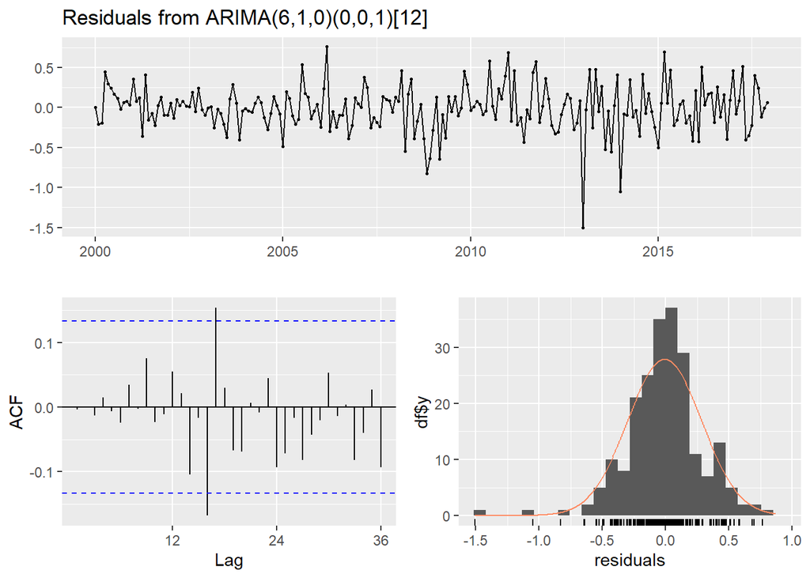

```
##
##  Ljung-Box test
##
## data:  Residuals from ARIMA(6,1,0)(0,0,1)[12]
## Q* = 22.671, df = 17, p-value = 0.1603
##
## Model df: 7.   Total lags used: 24
```

```r
# Check residuals of the inflation model
checkresiduals(sarima_inflation_portugal_1)
```

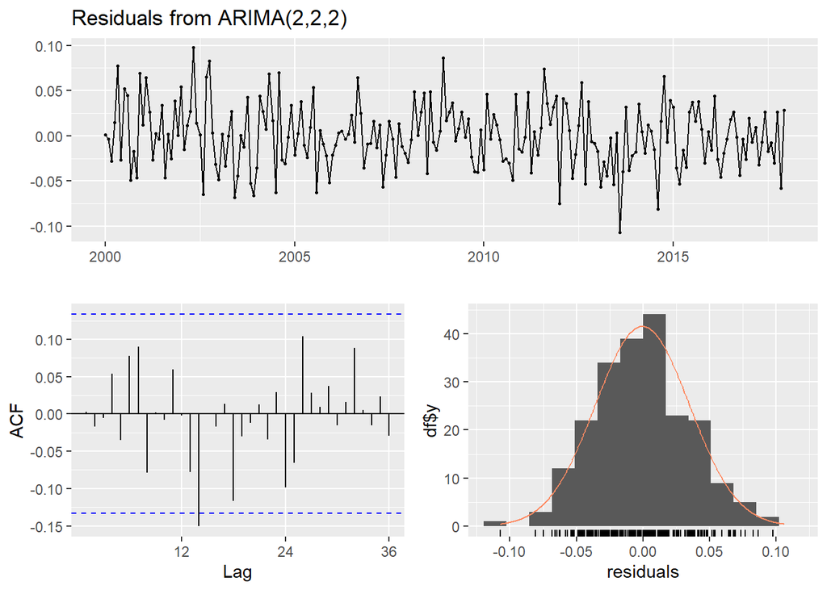

```
##
##  Ljung-Box test
##
## data:  Residuals from ARIMA(2,2,2)
## Q* = 19.605, df = 20, p-value = 0.4829
##
## Model df: 4.   Total lags used: 24
```

```r
# Check residuals of the unemployment model
checkresiduals(arima_unemployment_portugal_1)
```

Based on the Ljung-Box test p-value for residuals from both models are higher than 0.05 which means that the residuals are independently distributed and the models are well-specified. The residuals are behaving like a white noise, indicating that the models have captured the underlying patterns in the data effectively.